# Анализ оттока клиентов банка "Метанпромбанк"

Ссылка на презентацию https://disk.yandex.ru/i/wWIH70ljwv24Wg

**Описание проекта**

Отдел маркетинга банка "Метанпромбанк" инициировал проект по выявлению сегментов клиентов, проявляющих склонность к уходу из банка. Цель проекта отдела маркетинга заключается в разработке стратегий удержания клиентов на основе выявленных сегментов с целью достижения быстрых результатов. Отделения банка расположены в г. Ярославль, г. Ростов Великий и г. Рыбинск.

**Цель исследования:**

- Проанализировать клиентов регионального банка и выделить сегменты клиентов, которые склонны уходить из банка.
- Подготовить рекомендации для отдела маркетинга по удержанию клиентов для каждого сегмента, исходя из выявленных закономерностей.

**Задачи исследования:**

- Анализ данных и выявление корреляций.
- Создание профилей клиентов.
- Тестирование статистических гипотез.
- Формирование клиентских сегментов и их приоритизация в зависимости от уровня риска оттока из банка.
- Подготовка выводов и рекомендаций для маркетингового отдела.

**Описание данных:**

`/datasets/bank_scrooge.csv` - датасет содержит данные о клиентах банка «Метанпром». Банк располагается в Ярославле и областных городах: Ростов Великий и Рыбинск.

- `userid` — идентификатор пользователя,
- `score` — баллы кредитного скоринга,
- `city` — город,
- `gender` — пол,
- `age` — возраст,
- `equity` — количество баллов собственности (приблизительная оценка собственности клиента),
- `balance` — баланс на счёте,
- `products` — количество продуктов, которыми пользуется клиент,
- `credit_card` — есть ли кредитная карта,
- `last_activity` — был ли клиент активен последнее время,
- `est_salary` — оценочная заработная плата клиента
- `churn` — признак оттока.

## Общая информация

```python
!pip install phik
```

```python
# импортируем библиотеки
import pandas as pd
import numpy as np
import seaborn as sns
import matplotlib.pyplot as plt
import phik
from scipy import stats as st
import statsmodels.api as sm
import warnings
warnings.filterwarnings('ignore')
#%autosave 30
```

```python
# установка параметров отображения
pd.set_option('display.max_columns', None)  # отображает все столбцы

# снимаем ограничение на ширину столбцов
pd.set_option('display.max_colwidth', None)

# игнорируем предупреждения
pd.set_option('chained_assignment', None)
```

```python
# прочитаем датасет
try:
    data = pd.read_csv('https://code.s3.yandex.net/datasets/bank_scrooge.csv')
except:
    data = pd.read_csv('/datasets/bank_scrooge.csv')
```

```python
# напишем функцию для обзора данных
def review(data):
    display(data.head())
    print('---------------------------------------------------------------------------------------------------------')
    print(data.info())
    print('---------------------------------------------------------------------------------------------------------')
    print(data.duplicated().sum())
    print('---------------------------------------------------------------------------------------------------------')
    print(data.isna().sum())
    print('---------------------------------------------------------------------------------------------------------')
```

```python
review(data)
```

|  | USERID | score | city | gender | age | equity | balance | products | credit_card | last_activity | EST_SALARY | churn |
| --- | --- | --- | --- | --- | --- | --- | --- | --- | --- | --- | --- | --- |
| 0 | 183012 | 850.0 | Рыбинск | Ж | 25.0 | 1 | 59214.82 | 2 | 0 | 1 | 75719.14 | 1 |
| 1 | 146556 | 861.0 | Рыбинск | Ж | 37.0 | 5 | 850594.33 | 3 | 1 | 0 | 86621.77 | 0 |
| 2 | 120722 | 892.0 | Рыбинск | Ж | 30.0 | 0 | NaN | 1 | 1 | 1 | 107683.34 | 0 |
| 3 | 225363 | 866.0 | Ярославль | Ж | 51.0 | 5 | 1524746.26 | 2 | 0 | 1 | 174423.53 | 1 |
| 4 | 157978 | 730.0 | Ярославль | М | 34.0 | 5 | 174.00 | 1 | 1 | 0 | 67353.16 | 1 |

```
---------------------------------------------------------------------------------------------------------
<class 'pandas.core.frame.DataFrame'>
RangeIndex: 10000 entries, 0 to 9999
Data columns (total 12 columns):
 #   Column         Non-Null Count  Dtype
---  ------         --------------  -----
 0   USERID         10000 non-null  int64
 1   score          10000 non-null  float64
 2   city           10000 non-null  object
 3   gender         10000 non-null  object
 4   age            9974 non-null   float64
 5   equity         10000 non-null  int64
 6   balance        7705 non-null   float64
 7   products       10000 non-null  int64
 8   credit_card    10000 non-null  int64
 9   last_activity  10000 non-null  int64
 10  EST_SALARY     10000 non-null  float64
 11  churn          10000 non-null  int64
dtypes: float64(4), int64(6), object(2)
memory usage: 937.6+ KB
None
---------------------------------------------------------------------------------------------------------
0
---------------------------------------------------------------------------------------------------------
USERID              0
score               0
city                0
gender              0
age                26
equity              0
balance          2295
products            0
credit_card         0
last_activity       0
EST_SALARY          0
churn               0
dtype: int64
---------------------------------------------------------------------------------------------------------
```

Посмотрели общую информацию о датасете - в нем содержатся следующие типы данных и характеристики:

1. **Общая информация:**
   - датасет содержит 10,000 записей (строк) с индексами от 0 до 9999.
   - всего 12 столбцов (колонок).
2. **Столбцы и их типы данных:**
   - в датасете преобладают числовые данные: 4 столбца имеют тип float64 и 6 столбцов имеют тип int64.
   - Столбцы `city` и `gender` имеют тип object, что указывает на наличие строковых данных.

Возможно, имеет смысл сменить тип данных в следующих столбцах:

- `age`: можно рассмотреть использование типа int64, если возраст всегда является целым числом.
3. **Пропущенные значения:**
   - Столбцы `age` и `balance` имеют пропуски:
     - В столбце `age` отсутствует 26 значений из 10,000;
     - В столбце `balance` отсутствует 2,295 значений из 10,000

Определим, как с ними поступить позже.

4. **Наличие дубликатов:**
   - На первый взгляд в датасете не обнаружены дубликаты. Это свидетельствует о том, что каждая запись в датасете уникальна и не повторяется, что положительно сказывается на качестве данных и упрощает их анализ. Тем не менее, для полной уверенности проведём детальную проверку на наличие дублирующихся строк.

## Предобработка данных

### Переименование столбцов

Приведем названия столбцов к стилю snake_case

```python
# переименование столбцов в snake_case
data.rename(columns={
    'USERID': 'user_id',
    'EST_SALARY': 'est_salary'
}, inplace=True)
data.head()
```

|  | user_id | score | city | gender | age | equity | balance | products | credit_card | last_activity | est_salary | churn |
| --- | --- | --- | --- | --- | --- | --- | --- | --- | --- | --- | --- | --- |
| 0 | 183012 | 850.0 | Рыбинск | Ж | 25.0 | 1 | 59214.82 | 2 | 0 | 1 | 75719.14 | 1 |
| 1 | 146556 | 861.0 | Рыбинск | Ж | 37.0 | 5 | 850594.33 | 3 | 1 | 0 | 86621.77 | 0 |
| 2 | 120722 | 892.0 | Рыбинск | Ж | 30.0 | 0 | NaN | 1 | 1 | 1 | 107683.34 | 0 |
| 3 | 225363 | 866.0 | Ярославль | Ж | 51.0 | 5 | 1524746.26 | 2 | 0 | 1 | 174423.53 | 1 |
| 4 | 157978 | 730.0 | Ярославль | М | 34.0 | 5 | 174.00 | 1 | 1 | 0 | 67353.16 | 1 |

### Обработка типов данных

```python
# замена типа данных столбца age на int64
data['age'] = data['age'].astype('Int64')
```

### Кодирование данных

Создадим новые столбцы с данными о поле и городе

```python
data['city_new'] = data['city']
data['gender_new'] = data['gender']
data.head()
```

|  | user_id | score | city | gender | age | equity | balance | products | credit_card | last_activity | est_salary | churn | city_new | gender_new |
| --- | --- | --- | --- | --- | --- | --- | --- | --- | --- | --- | --- | --- | --- | --- |
| 0 | 183012 | 850.0 | Рыбинск | Ж | 25 | 1 | 59214.82 | 2 | 0 | 1 | 75719.14 | 1 | Рыбинск | Ж |
| 1 | 146556 | 861.0 | Рыбинск | Ж | 37 | 5 | 850594.33 | 3 | 1 | 0 | 86621.77 | 0 | Рыбинск | Ж |
| 2 | 120722 | 892.0 | Рыбинск | Ж | 30 | 0 | NaN | 1 | 1 | 1 | 107683.34 | 0 | Рыбинск | Ж |
| 3 | 225363 | 866.0 | Ярославль | Ж | 51 | 5 | 1524746.26 | 2 | 0 | 1 | 174423.53 | 1 | Ярославль | Ж |
| 4 | 157978 | 730.0 | Ярославль | М | 34 | 5 | 174.00 | 1 | 1 | 0 | 67353.16 | 1 | Ярославль | М |

Используем функцию `pd.get_dummies` для кодирования столбцов `city` и `gender`:

```python
# кодирование city_new и gender_new
data = pd.get_dummies(data, dtype=int, columns=['gender_new'], drop_first=True)
data = pd.get_dummies(data, dtype=int, columns=['city_new'], drop_first=False)

# переименование столбцов
data = data.rename(columns={
    'gender_new_М': 'Пол',
    'city_new_Рыбинск': 'Рыбинск',
    'city_new_Ростов': 'Ростов',
    'city_new_Ярославль': 'Ярославль'
})

# выводим результат
display(data.head())
```

|  | user_id | score | city | gender | age | equity | balance | products | credit_card | last_activity | est_salary | churn | Пол | Ростов | Рыбинск | Ярославль |
| --- | --- | --- | --- | --- | --- | --- | --- | --- | --- | --- | --- | --- | --- | --- | --- | --- |
| 0 | 183012 | 850.0 | Рыбинск | Ж | 25 | 1 | 59214.82 | 2 | 0 | 1 | 75719.14 | 1 | 0 | 0 | 1 | 0 |
| 1 | 146556 | 861.0 | Рыбинск | Ж | 37 | 5 | 850594.33 | 3 | 1 | 0 | 86621.77 | 0 | 0 | 0 | 1 | 0 |
| 2 | 120722 | 892.0 | Рыбинск | Ж | 30 | 0 | NaN | 1 | 1 | 1 | 107683.34 | 0 | 0 | 0 | 1 | 0 |
| 3 | 225363 | 866.0 | Ярославль | Ж | 51 | 5 | 1524746.26 | 2 | 0 | 1 | 174423.53 | 1 | 0 | 0 | 0 | 1 |
| 4 | 157978 | 730.0 | Ярославль | М | 34 | 5 | 174.00 | 1 | 1 | 0 | 67353.16 | 1 | 1 | 0 | 0 | 1 |

### Обработка пропущенных значений

Посмотрим на уникальные значения столбца `age`.

```python
print (data['age'].unique())
```

```
<IntegerArray>
[  25,   37,   30,   51,   34,   56,   39,   38,   54,   67,   52,   41,   31,
   28,   35,   42,   45,   53,   40,   43,   47,   48,   61,   62,   36,   26,
   27,   60,   72,   50,   46,   55,   58,   71,   44,   49,   33,   32,   66,
   29,   68,   73,   69,   59,   21,   65,   57,   63,   80,   24,   70,   77,
   64,   23,   20,   18,   19,   78,   74,   76,   22,   75, <NA>,   83,   82,
   81,   84,   79,   86]
Length: 69, dtype: Int64
```

```python
# найдём % пропусков по столбцу 'age'
data['age'].isna().sum()/len(data)*100
```

```
0.26
```

Пропущенных значений слишком мало, чтоб они могли повлиять на анализ.  
Предлагаю заменить медианным значением.

```python
data['age'] = data['age'].fillna(data['age'].median())
# проверка
data.age.isnull().sum()
```

```
0
```

Проверим пропуски в столбце `balance`:

```python
# найдём % пропусков по столбцу 'balance'
data['balance'].isna().sum()/len(data)*100
```

```
22.95
```

Пропущенные значения занимают 23% - довольно большое количество, чтобы просто удалить.  
Давайте детально рассмотрим пропуски в столбце "баланс", чтобы принять обоснованное решение. Для этого мы создадим новый признак, который будет равен 1, если в записи отсутствует значение, и 0, если значение присутствует.

```python
data_new = data.copy()
```

```python
# здесь data['missing_balance'] будет равен 1, если значение в столбце balance пропущено, и 0 - если оно присутствует.
data_new['missing_balance'] = data_new['balance'].isnull().astype(int)
```

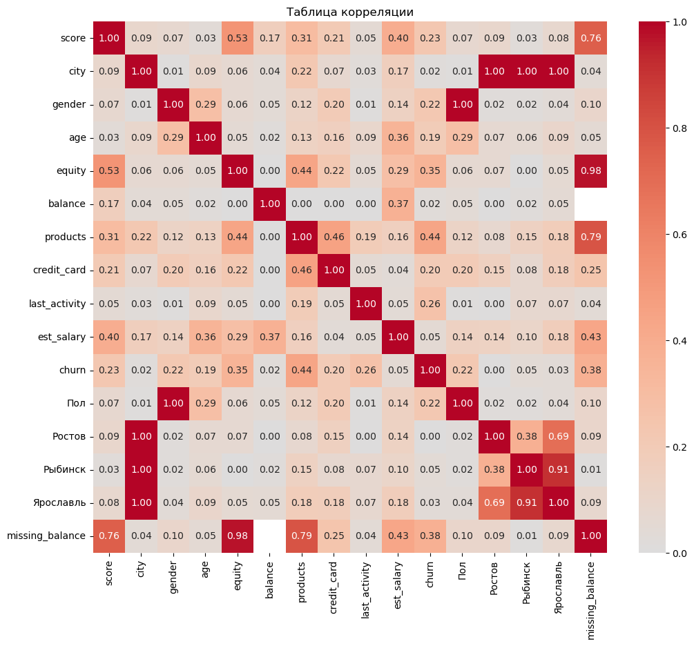

```python
# проверяем и удаляем столбец user_id т.к. содержит много уникальных значений
if 'user_id' in data_new.columns:
    data_new.drop('user_id', axis=1, inplace=True)

# вычисляем корреляционную матрицу phik
interval_cols = ['balance', 'est_salary', 'score', 'churn', 'age']
phik_matrix = data_new.phik_matrix(interval_cols=interval_cols)

# визуализируем корреляционную матрицу с помощью heatmap
fig, axes = plt.subplots(figsize=(12, 10))
sns.heatmap(phik_matrix,
            annot=True,
            fmt='.2f',
            cmap='coolwarm',
            center=0,
            ax=axes)
plt.title('Таблица корреляции')
plt.show()
```

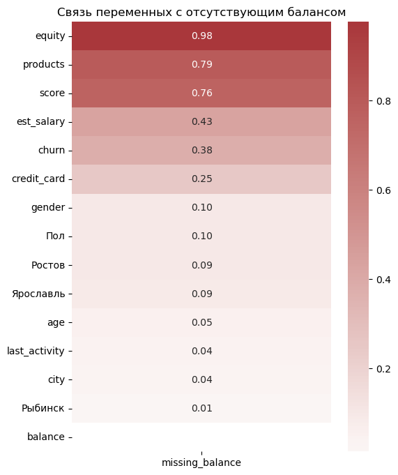

```python
# извлекаем столбец 'missing_balance' из матрицы корреляции
missing_balance_corr = phik_matrix[['missing_balance']].drop('missing_balance').sort_values(by='missing_balance', ascending=False)

# Визуализация корреляций с помощью heatmap
fig, ax = plt.subplots(figsize=(6, 8))
sns.heatmap(missing_balance_corr,
            annot=True,
            fmt='.2f',
            cmap='vlag',
            center=0,
            ax=ax)
plt.title('Связь переменных с отсутствующим балансом')
plt.show()
```

Это указывает на то, что пропуски в данных зависят от других признаков, и их нельзя игнорировать.

Следовательно, можно заключить, что данные относятся к типу **MNAR (Missing Not At Random / Отсутствует не случайно)** — пропуски зависят от данных. Без дополнительного обоснования их нельзя отбрасывать или заполнять одним значением, так как это приведёт к заметным искажениям.

Таким образом, убирать пропуски или заменять их значениями не будем, чтобы не изменить итоговый результат исследования.

### Обработка дубликатов

```python
# проверка на наличие дублирующихся строк
duplicates = data.duplicated()
if duplicates.any():
    print(f"Найдено {duplicates.sum()} дублирующихся строк.")
else:
    print("Дублирующиеся строки отсутствуют.")
```

```
Дублирующиеся строки отсутствуют.
```

```python
# поиск дубликатов в 'user_id'
print(data.duplicated(subset=['user_id']).sum())
```

```
73
```

```python
duplicates = data[data['user_id'].duplicated(keep=False)]
display(duplicates)
```

|  | user_id | score | city | gender | age | equity | balance | products | credit_card | last_activity | est_salary | churn | Пол | Ростов | Рыбинск | Ярославль |
| --- | --- | --- | --- | --- | --- | --- | --- | --- | --- | --- | --- | --- | --- | --- | --- | --- |
| 7 | 218868 | 825.0 | Ярославль | Ж | 38 | 4 | 458145.40 | 2 | 1 | 1 | 68085.48 | 0 | 0 | 0 | 0 | 1 |
| 58 | 164676 | 860.0 | Ярославль | М | 37 | 5 | 648594.03 | 2 | 1 | 1 | 213586.86 | 1 | 1 | 0 | 0 | 1 |
| 150 | 185748 | 850.0 | Рыбинск | М | 36 | 5 | 1203376.67 | 2 | 0 | 1 | 89401.82 | 1 | 1 | 0 | 1 | 0 |
| 161 | 197364 | 928.0 | Рыбинск | Ж | 53 | 6 | 1347183.86 | 2 | 0 | 1 | 168189.49 | 1 | 0 | 0 | 1 | 0 |
| 231 | 190253 | 823.0 | Рыбинск | М | 37 | 4 | 373348.39 | 2 | 0 | 1 | 131947.92 | 1 | 1 | 0 | 1 | 0 |
| ... | ... | ... | ... | ... | ... | ... | ... | ... | ... | ... | ... | ... | ... | ... | ... | ... |
| 9775 | 124450 | 758.0 | Рыбинск | Ж | 36 | 0 | 73574.07 | 2 | 0 | 1 | 79963.59 | 0 | 0 | 0 | 1 | 0 |
| 9785 | 168998 | 895.0 | Рыбинск | М | 44 | 0 | 282653.53 | 3 | 0 | 0 | 255296.47 | 0 | 1 | 0 | 1 | 0 |
| 9819 | 140934 | 832.0 | Рыбинск | Ж | 40 | 3 | 385763.16 | 2 | 0 | 1 | 59651.35 | 0 | 0 | 0 | 1 | 0 |
| 9880 | 217412 | 886.0 | Ярославль | Ж | 35 | 3 | 1026172.14 | 2 | 1 | 0 | 53099.16 | 0 | 0 | 0 | 0 | 1 |
| 9970 | 175730 | 816.0 | Рыбинск | М | 36 | 4 | 477892.07 | 3 | 1 | 0 | 81100.60 | 0 | 1 | 0 | 1 | 0 |

146 rows × 16 columns

Проверим случайные идентификаторы пользователя.

```python
data.loc[data['user_id'] == 164676]
```

|  | user_id | score | city | gender | age | equity | balance | products | credit_card | last_activity | est_salary | churn | Пол | Ростов | Рыбинск | Ярославль |
| --- | --- | --- | --- | --- | --- | --- | --- | --- | --- | --- | --- | --- | --- | --- | --- | --- |
| 58 | 164676 | 860.0 | Ярославль | М | 37 | 5 | 648594.03 | 2 | 1 | 1 | 213586.86 | 1 | 1 | 0 | 0 | 1 |
| 7271 | 164676 | 790.0 | Рыбинск | Ж | 77 | 1 | 111202.01 | 1 | 1 | 0 | 32835.45 | 0 | 0 | 0 | 1 | 0 |

```python
data.loc[data['user_id'] == 175730]
```

|  | user_id | score | city | gender | age | equity | balance | products | credit_card | last_activity | est_salary | churn | Пол | Ростов | Рыбинск | Ярославль |
| --- | --- | --- | --- | --- | --- | --- | --- | --- | --- | --- | --- | --- | --- | --- | --- | --- |
| 7753 | 175730 | 846.0 | Ярославль | Ж | 32 | 7 | 216764.74 | 4 | 1 | 1 | 77100.85 | 1 | 0 | 0 | 0 | 1 |
| 9970 | 175730 | 816.0 | Рыбинск | М | 36 | 4 | 477892.07 | 3 | 1 | 0 | 81100.60 | 0 | 1 | 0 | 1 | 0 |

```python
data.loc[data['user_id'] == 124450]
```

|  | user_id | score | city | gender | age | equity | balance | products | credit_card | last_activity | est_salary | churn | Пол | Ростов | Рыбинск | Ярославль |
| --- | --- | --- | --- | --- | --- | --- | --- | --- | --- | --- | --- | --- | --- | --- | --- | --- |
| 8164 | 124450 | 859.0 | Ярославль | Ж | 38 | 6 | 516811.20 | 1 | 1 | 1 | 95144.63 | 1 | 0 | 0 | 0 | 1 |
| 9775 | 124450 | 758.0 | Рыбинск | Ж | 36 | 0 | 73574.07 | 2 | 0 | 1 | 79963.59 | 0 | 0 | 0 | 1 | 0 |

Для проверки наличия дубликатов были выбраны три случайные пары идентификаторов клиента. После анализа данных было установлено, что эти значения не являются дубликатами. Например, user_id `164676` присутствует у двух различных клиентов: один продолжает обслуживание в нашем банке (churn=0), другой прекратил обслуживание (churn=1). Таким образом, делаем вывод, что данные строки не являются дубликатами.

**Проведем проверку на неявные дубликаты**

```python
# создадим функцию
def check_unique_values(data, columns):
    unique_values = {}
    for column in columns:
        unique_values[column] = data[column].unique()
    return unique_values

# Список столбцов для проверки
columns_to_check = ['city', 'gender', 'credit_card', 'last_activity', 'churn']

# Выполняем проверку
unique_values = check_unique_values(data, columns_to_check)

# Выводим результаты
for column, values in unique_values.items():
    print(f'Уникальные значения в столбце "{column}": {values}')
```

```
Уникальные значения в столбце "city": ['Рыбинск' 'Ярославль' 'Ростов']
Уникальные значения в столбце "gender": ['Ж' 'М']
Уникальные значения в столбце "credit_card": [0 1]
Уникальные значения в столбце "last_activity": [1 0]
Уникальные значения в столбце "churn": [1 0]
```

Все в порядке. Работу с дубликатами завершаем.

### Проверка на выбросы

```python
# используем метод describe для анализа распределения данных в столбцах датасета:
pd.set_option("display.float_format", "{:.2f}".format) #установка формата отображения чисел
data.describe()
```

|  | user_id | score | age | equity | balance | products | credit_card | last_activity | est_salary | churn | Пол | Ростов | Рыбинск | Ярославль |
| --- | --- | --- | --- | --- | --- | --- | --- | --- | --- | --- | --- | --- | --- | --- |
| count | 10000.00 | 10000.00 | 10000.00 | 10000.00 | 7705.00 | 10000.00 | 10000.00 | 10000.00 | 10000.00 | 10000.00 | 10000.00 | 10000.00 | 10000.00 | 10000.00 |
| mean | 171814.71 | 848.70 | 42.73 | 2.63 | 827794.31 | 1.87 | 0.68 | 0.52 | 147866.89 | 0.18 | 0.50 | 0.14 | 0.27 | 0.59 |
| std | 33708.24 | 65.45 | 12.16 | 1.98 | 1980614.15 | 0.79 | 0.47 | 0.50 | 139388.51 | 0.39 | 0.50 | 0.35 | 0.44 | 0.49 |
| min | 94561.00 | 642.00 | 18.00 | 0.00 | 0.00 | 0.00 | 0.00 | 0.00 | 2546.30 | 0.00 | 0.00 | 0.00 | 0.00 | 0.00 |
| 25% | 142810.25 | 802.00 | 33.00 | 0.00 | 295554.16 | 1.00 | 0.00 | 0.00 | 75251.90 | 0.00 | 0.00 | 0.00 | 0.00 | 0.00 |
| 50% | 172728.00 | 853.00 | 40.00 | 3.00 | 524272.20 | 2.00 | 1.00 | 1.00 | 119658.10 | 0.00 | 1.00 | 0.00 | 0.00 | 1.00 |
| 75% | 201261.75 | 900.00 | 51.00 | 4.00 | 980705.85 | 2.00 | 1.00 | 1.00 | 174500.54 | 0.00 | 1.00 | 0.00 | 1.00 | 1.00 |
| max | 229145.00 | 1000.00 | 86.00 | 9.00 | 119113552.01 | 5.00 | 1.00 | 1.00 | 1395064.45 | 1.00 | 1.00 | 1.00 | 1.00 | 1.00 |

Проверим минимальное значение `0` в столбце `products`- в датасете есть клиенты без продуктов.

```python
# подсчет количества клиентов без продуктов
clients_without_products = data[data['products'] == 0]['user_id'].nunique()
print(f"Количество клиентов без продуктов: {clients_without_products}")
```

```
Количество клиентов без продуктов: 1
```

```python
# поиск клиента, у которого 'products' равно 0
client_zero = data[data['products'] == 0]
client_zero
```

|  | user_id | score | city | gender | age | equity | balance | products | credit_card | last_activity | est_salary | churn | Пол | Ростов | Рыбинск | Ярославль |
| --- | --- | --- | --- | --- | --- | --- | --- | --- | --- | --- | --- | --- | --- | --- | --- | --- |
| 8957 | 147837 | 962.00 | Рыбинск | Ж | 79 | 3 | NaN | 0 | 0 | 0 | 25063.96 | 1 | 0 | 0 | 1 | 0 |

```python
# замена значений 0 на 1 в столбце 'products'
data['products'] = data['products'].replace(0, 1)
```

Возможные выбросы:

- `Balance`: присутствует большой разброс, особенно заметно высокое максимальное значение. Это может потребовать дальнейшего анализа, чтобы понять причины таких аномалий.
- `Score`: с максимальным значением 1000, но с широким стандартным отклонением (65.45) указывает на то, что некоторые клиенты могут иметь очень низкие или высокие оценки.
- `Age`: возраст пользователей варьируется от 18 до 86 лет, однако стандартное отклонение (12.16) меньше, чем для других переменных, что может говорить о более однородной группе в этом отношении.
- Значения `equity, credit_card, last_activity` не показывают значительных выбросов и распределены равномерно.

Проверим распределение непрерывных величин на следующих шагах.

**Вывод по разделу:**

Выполнена предобработка данных:

- Столбцы `USERID` и `EST_SALARY` были приведены к единому стилю.
- Тип данных в столбце age изменён с float на int.
- Выполнено кодирование данных в столбцах `gender` и `city` для упрощения дальнейших расчетов.
- Обработаны пропущенные значения:
  - пропуски в столбце `age` заменены медианным значением,
  - пропуски в столбце `balance` признаны MNAR и оставлены без изменений.
- Полные дубликаты не обнаружены.
- Проведен анализ дубликатов в столбце user_id.
- Выведена описательная статистика на предмет изучения выбросов.

## Исследовательский анализ данных

### Корреляционный анализ

Построим корреляцию между оттоком клиентов и другими параметрами в датасете:

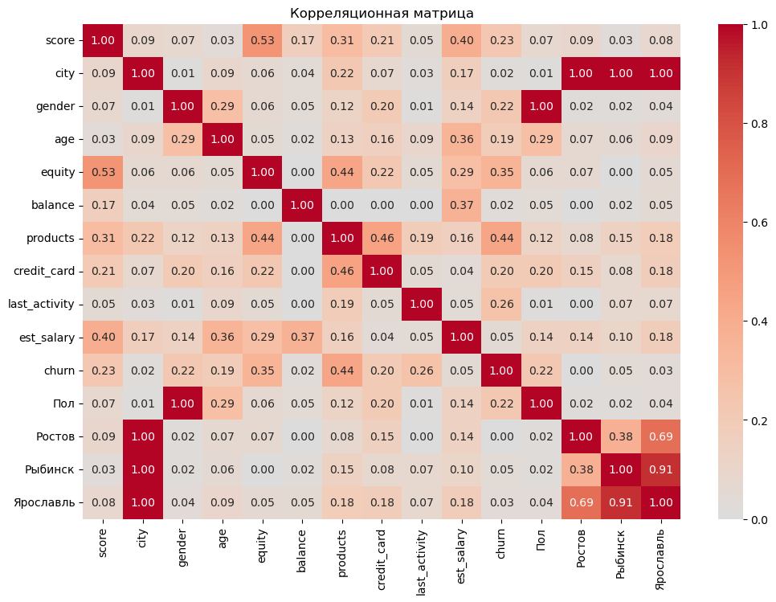

```python
if 'missing_balance' in data_new.columns:
    # удаляем столбец из data_new
    data_new.drop('missing_balance', axis=1, inplace=True)

# определение интервальных столбцов
interval_cols = ['score', 'age', 'balance', 'est_salary']

# расчет phik матрицы корреляции на обновленных данных
phik_matrix = data_new.phik_matrix(interval_cols=interval_cols)

# визуализация phik матрицы корреляции для всех параметров
plt.figure(figsize=(12, 8))
sns.heatmap(phik_matrix, annot=True, cmap='coolwarm', center=0, fmt='.2f', vmin=0, vmax=1)
plt.title('Корреляционная матрица')
plt.show()
```

Для интерпретации силы корреляции используем шкалу Чеддока:

- 0.0–0.1: Очень слабая
- 0.1–0.3: Слабая
- 0.3–0.5: Умеренная
- 0.5–0.7: Заметная
- 0.7–0.9: Высокая
- 0.9–1.0: Очень высокая
- Параметры с заметной и умеренной корреляцией:

Параметры `equity и products` имеют наиболее значительную корреляцию с другими параметрами, что может указывать на их важность в анализе данных.

Отток клиентов `churn` наиболее сильно коррелирует с `products и equity`, что делает эти параметры ключевыми для прогнозирования оттока клиентов.

- Параметры со слабой и очень слабой корреляцией:

Параметры `city, gender, и balance` имеют слабую или очень слабую корреляцию с большинством других параметров, что может указывать на их меньшую значимость в прогнозировании оттока клиентов.

```
churn           1.00
products        0.44
equity          0.35
last_activity   0.26
score           0.23
gender          0.22
Пол             0.22
credit_card     0.20
age             0.19
est_salary      0.05
Рыбинск         0.05
Ярославль       0.03
balance         0.02
city            0.02
Ростов          0.00
Name: churn, dtype: float64
```

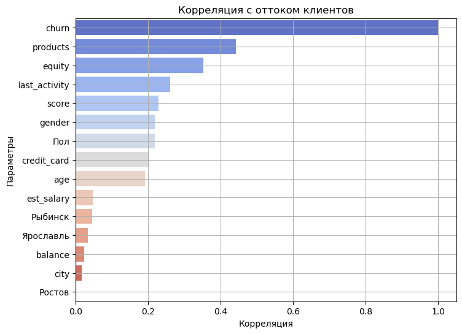

```python
# фильтрация корреляций только с оттоком клиентов (churn)
phik_with_churn = phik_matrix['churn'].sort_values(ascending=False)
print(phik_with_churn)

# визуализация корреляций только с оттоком клиентов
plt.figure(figsize=(8, 6))
sns.barplot(x=phik_with_churn.values, y=phik_with_churn.index, palette='coolwarm')
plt.title('Корреляция с оттоком клиентов')
plt.xlabel('Корреляция')
plt.ylabel('Параметры')
plt.grid()
plt.show()
```

Остальные параметры (est_salary, city, balance) имеют минимальное влияние на отток клиентов.

### Анализ распределения непрерывных данных

Исследуем распределения непрерывных переменных с выделением групп по уровню оттока.

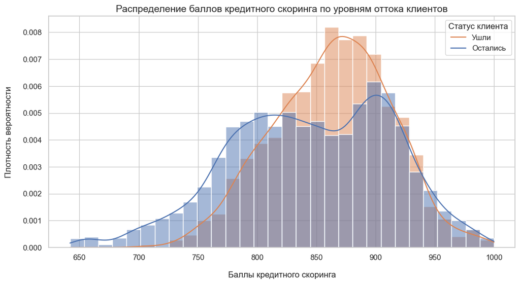

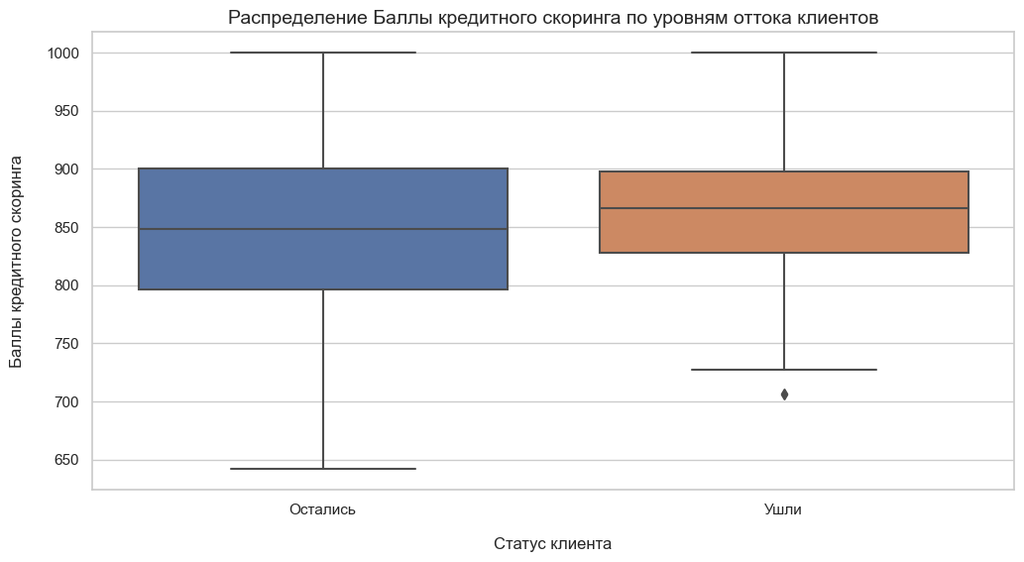

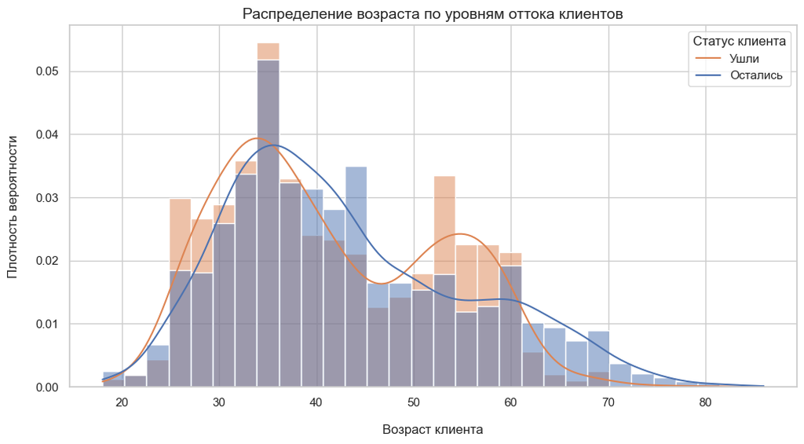

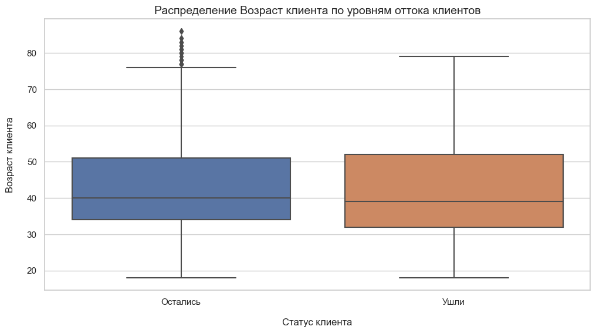

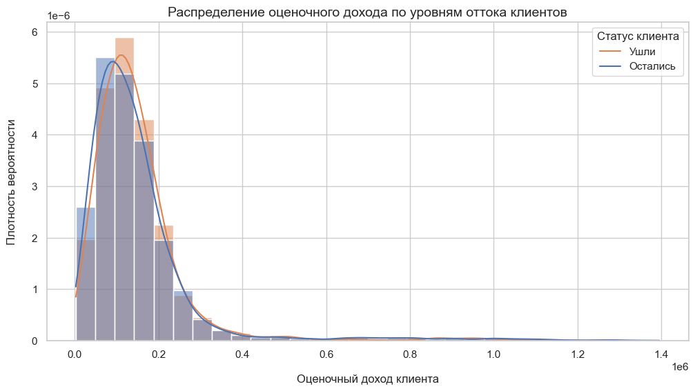

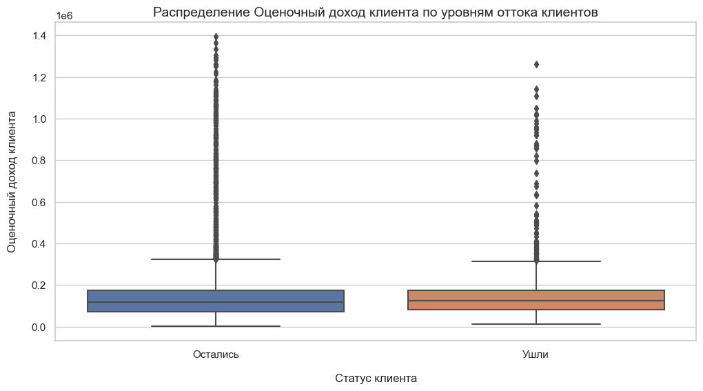

```python
# установим стиль графиков
sns.set(style="whitegrid")

# создание графиков
variables = ['score', 'age', 'est_salary']

# словарь с названиями для каждого графика
titles = {
    'score': 'Распределение баллов кредитного скоринга по уровням оттока клиентов',
    'age': 'Распределение возраста по уровням оттока клиентов',
    'est_salary': 'Распределение оценочного дохода по уровням оттока клиентов'

}

# словарь с подписями для оси X
x_labels = {
    'score': 'Баллы кредитного скоринга',
    'age': 'Возраст клиента',
    'est_salary': 'Оценочный доход клиента'

}

# для построения графика необходимо преобразовать в float
data['age'] = data['age'].astype(float)

# функция для построения гистограммы и боксплота
def plot_hist_and_box(var):
    # гистограмма
    plt.figure(figsize=(12, 6))
    sns.histplot(data=data, x=var, hue='churn', bins=30, stat='density', common_norm=False, kde=True)
    plt.title(titles[var], fontsize=14)
    plt.xlabel(x_labels[var], fontsize=12, labelpad=15)
    plt.ylabel('Плотность вероятности', fontsize=12, labelpad=15)
    plt.legend(title='Статус клиента', loc='upper right', labels=['Ушли', 'Остались'])
    plt.show()

    # боксплот
    plt.figure(figsize=(12, 6))
    sns.boxplot(x='churn', y=var, data=data)
    plt.title(f'Распределение {x_labels[var]} по уровням оттока клиентов', fontsize=14)
    plt.xlabel('Статус клиента', fontsize=12, labelpad=15)
    plt.ylabel(x_labels[var], fontsize=12, labelpad=15)
    plt.xticks(ticks=[0, 1], labels=['Остались', 'Ушли'])
    plt.show()

# построение графиков для каждой переменной
for var in variables:
    plot_hist_and_box(var)
```

Построим дополнительную гистограмму для `est_salary`, установив ограничение по оси Х:

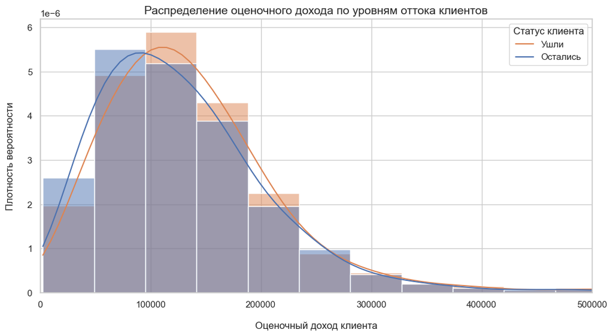

```python
# гистограмма с ограничением по оси X
plt.figure(figsize=(12, 6))
sns.histplot(data=data, x='est_salary', hue='churn', bins=30, kde=True, stat='density', common_norm=False)
plt.title(titles['est_salary'], fontsize=14)
plt.xlabel(x_labels['est_salary'], fontsize=12, labelpad=15)
plt.ylabel('Плотность вероятности', fontsize=12, labelpad=15)
plt.legend(title='Статус клиента', loc='upper right', labels=['Ушли', 'Остались'])
plt.xlim(0, 500000)  # ограничение по оси X
plt.show()
```

**Выводы по графикам:**

**Кредитные баллы (score):**

- Клиенты, покидающие банк, в среднем имеют более высокие кредитные баллы, чем оставшиеся.
- Всплеск наблюдается в интервале 830, наибольший рост в интервале 830-900 баллов, далее между 900 и 950 также наблюдаются всплески.
- Медианное значение score у ушедших клиентов выше, размах значений меньше, что может свидетельствовать о наличии клиентов с высоким скорингом.

**Оценочный доход (est_salary):**

- Большинство клиентов банка имеет оценочный доход от 50 тыс. до 150 тыс. руб., уровеннь оттока растет при доходе в 100-200 тыс.руб.
- Медианный доход у клиентов, склонных к оттоку, и тех, кто остаётся, практически одинаков, что указывает на отсутствие значительной разницы в доходах между этими группами.

Распределение по балансу построим отдельно, так в данных большое количество выбивающихся значений.

```python
# найдем максимальное значение баланса
max_balance = data['balance'].max()
print(f'Максимальный баланс: {max_balance}')

# подсчет количества клиентов с максимальным балансом
count_max_balances = (data['balance'] == max_balance).sum()
print(f'Количество клиентов с максимальным балансом: {count_max_balances}')
```

```
Максимальный баланс: 119113552.01
Количество клиентов с максимальным балансом: 1
```

Максимальный баланс принадлежит всего одному клиенту. Это означает, что этот случай представляет собой уникальную аномалию, которая может не отражать общую тенденцию среди других клиентов. В связи с этим целесообразно сосредоточиться на более средних значениях, таких как медиана или среднее арифметическое, чтобы получить более объективное представление о финансовом состоянии большинства клиентов.

Изучение этих средних показателей позволит лучше понимать поведение и потребности основной массы пользователей, а также выявлять потенциальные возможности для улучшения обслуживания и удержания клиентов, что является важным для долгосрочной стратегии бизнеса.

Таким образом, дальнейший анализ следует проводить с акцентом на более стабильные данные, что поможет избежать искажений, вызванных экстраординарными случаями.

Найдем средние значения

```python
data['balance'].describe()
```

```
count        7705.00
mean       827794.31
std       1980614.15
min             0.00
25%        295554.16
50%        524272.20
75%        980705.85
max     119113552.01
Name: balance, dtype: float64
```

Большинство значений находятся в диапазоне до 1,000,000, о чем свидетельствуют значения квартилей. Лишь небольшое количество клиентов имеют экстремально высокие балансы. Возьмем за границу среднее значение (median/mean)

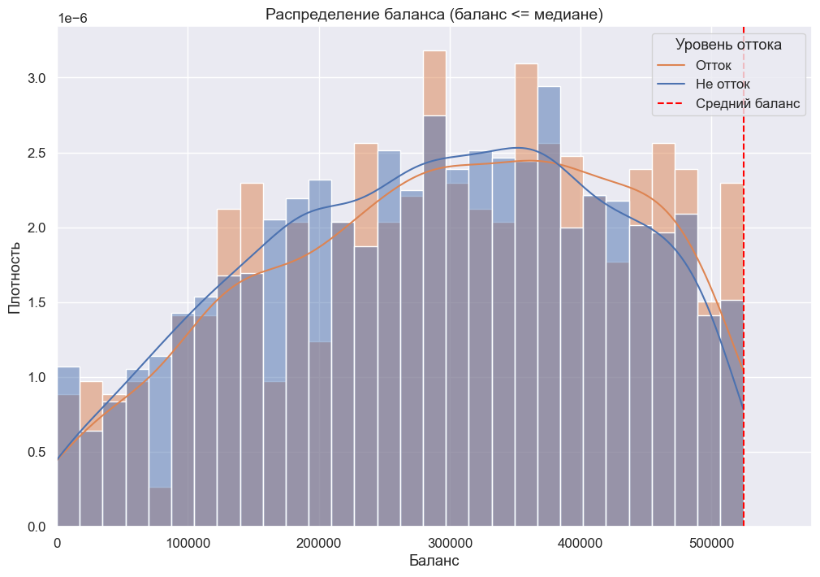

```python
# определяем среднее значение баланса
median_balance = data['balance'].median()

# фильтруем данные для баланса, ограничивая средним значением
filtered_bal = data.query(f'balance <= {median_balance}')

# построение гистограммы
plt.figure(figsize=(12, 8))
sns.set(font_scale=1.1)
histplot = sns.histplot(data=filtered_bal, x='balance', hue='churn', bins=30, kde=True, stat='density', common_norm=False)

# добавление линии среднего значения
plt.axvline(median_balance, color='red', linestyle='--', label='Средний баланс')

# настройка заголовков и подписей
histplot.set_title('Распределение баланса (баланс <= медиане)', fontsize=14)
histplot.set_xlabel('Баланс')
histplot.set_ylabel('Плотность')

# настройка легенды
plt.legend(title='Уровень оттока', labels=['Отток', 'Не отток', 'Средний баланс'], loc='upper right')

# установка пределов для оси X
plt.xlim(0, median_balance * 1.1)  # оставляем немного пространства справа

plt.show()
```

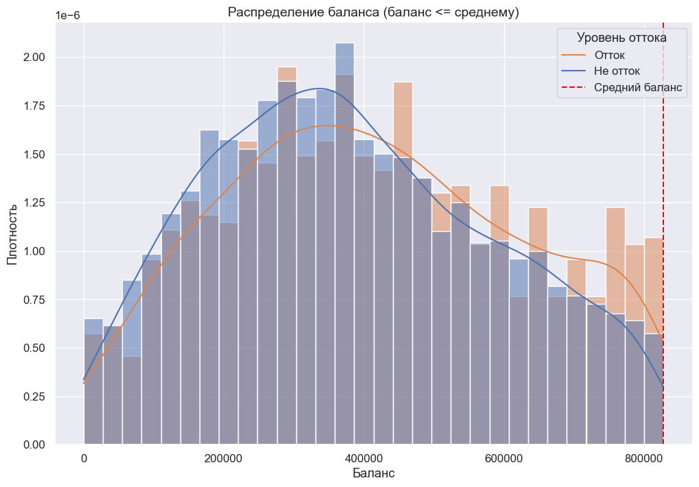

```python
# определяем среднее значение баланса
mean_balance = data['balance'].mean()

# фильтруем данные для баланса, ограничивая средним значением
filtered_bal = data.query(f'balance <= {mean_balance}')

# построение гистограммы
plt.figure(figsize=(12, 8))
sns.set(font_scale=1.1)
histplot = sns.histplot(data=filtered_bal, x='balance', hue='churn', bins=30, kde=True, stat='density', common_norm=False)

# добавление линии среднего значения
plt.axvline(mean_balance, color='red', linestyle='--', label='Средний баланс')

# настройка заголовков и подписей
histplot.set_title('Распределение баланса (баланс <= среднему)', fontsize=14)
histplot.set_xlabel('Баланс')
histplot.set_ylabel('Плотность')

# настройка легенды
plt.legend(title='Уровень оттока', labels=['Отток', 'Не отток', 'Средний баланс'], loc='upper right')

# установка пределов для оси X
#plt.xlim(0, mean_balance * 1.1)  # оставляем немного пространства справа

plt.show()
```

Гистограмма распределения балансов клиентов, ограниченная средним значением, показывает, что большая часть клиентов имеет балансы ниже среднего. Однако наблюдается некоторое количество клиентов с существенно более высокими значениями, что может указывать на наличие нескольких "богатых" клиентов, влияющих на среднее значение. Также видно, что клиенты с высоким балансом более склонны к оттоку. Кривая плотности показывает, что большинство клиентов имеет баланс в диапазоне от 0 до 500,000, с некоторыми пиками в этом диапазоне, что может свидетельствовать о характерных чертах клиентской базы.

**Построим распределение для баланса с установленным лимитом в 5 миллионов:**

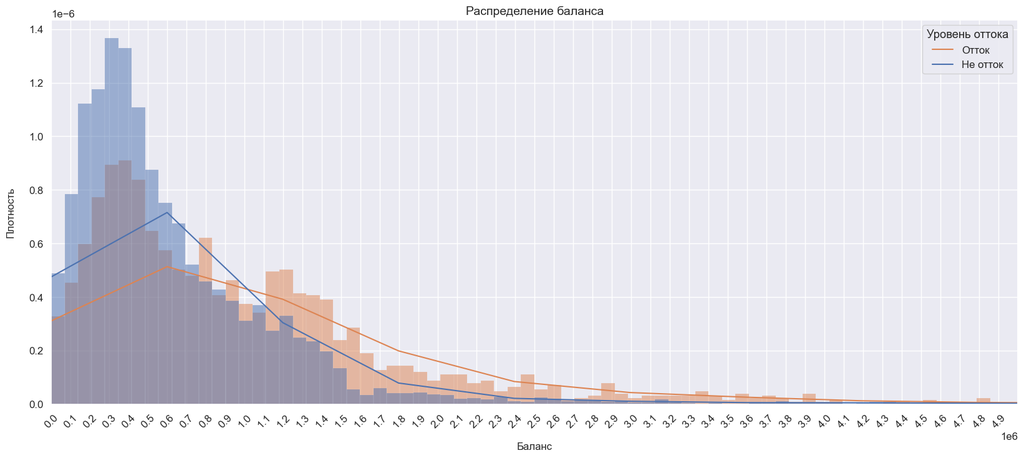

```python
plt.figure(figsize=(20, 8))

# строим гистограмму
sns.histplot(data, x='balance', hue='churn',stat='density', common_norm=False, kde=True)

# настройка заголовков и подписей
plt.title('Распределение баланса', fontsize=14)
plt.xlabel('Баланс', fontsize=12, labelpad=15)
plt.ylabel('Плотность', fontsize=12, labelpad=15)

# настройка пределов оси X
plt.xlim(0, 5000000)

# установка меток на оси X
plt.xticks(range(0, 5000000, 100000), rotation=45)  # rotation для легкости чтения меток

# настройка легенды
plt.legend(title='Уровень оттока', labels=['Отток', 'Не отток'], loc='upper right')

plt.show()
```

Вероятность оттока растёт у клиентов с балансами от 750 тыс. руб. вплоть до 4 млн.руб.

### Оценка уровней оттока по параметрам

#### Количество продуктов (products)

```python
# подсчет количества клиентов в зависимости от числа используемых продуктов
product_counts = data['products'].value_counts()
product_counts
```

```
products
2    5126
1    3342
3    1039
4     474
5      19
Name: count, dtype: int64
```

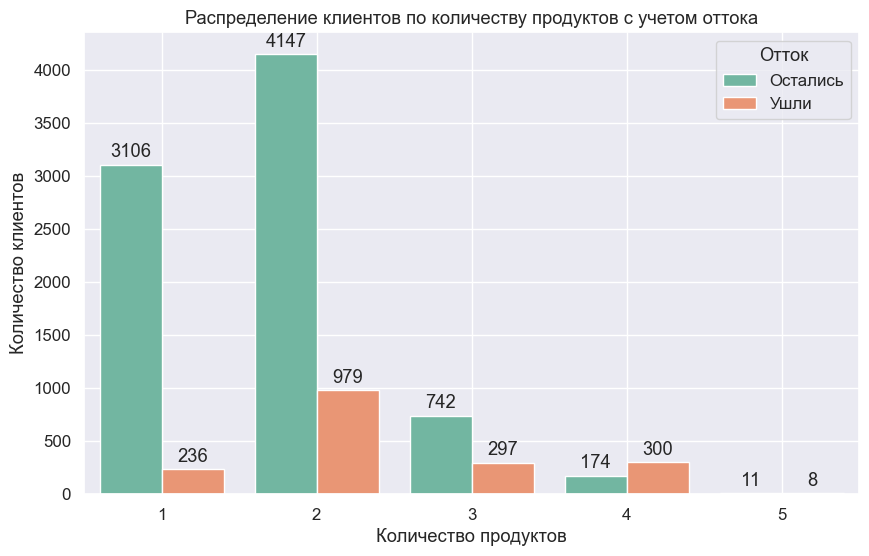

```python
# группировка данных по продуктам и оттоку
grouped_products = data.groupby(['products', 'churn']).size().reset_index(name='Количество клиентов')

# построение столбчатой диаграммы
plt.figure(figsize=(10, 6))
barplot = sns.barplot(x='products', y='Количество клиентов', data=grouped_products, hue='churn', dodge=True, palette='Set2')

# добавление подписей на столбцы
for p in barplot.patches:
    barplot.annotate(format(p.get_height(), '.0f'),
                     (p.get_x() + p.get_width() / 2., p.get_height()),
                     ha='center', va='center',
                     xytext=(0, 9),
                     textcoords='offset points')

# настройка меток и заголовка
plt.xlabel('Количество продуктов')
plt.ylabel('Количество клиентов')
plt.title('Распределение клиентов по количеству продуктов с учетом оттока')
plt.grid(True)

# настройка легенды
handles, labels = barplot.get_legend_handles_labels()
new_labels = ['Остались', 'Ушли']
plt.legend(handles, new_labels, title='Отток', loc='upper right')
plt.show()
```

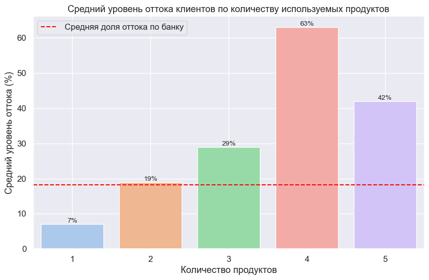

```python
# создание сводной таблицы с уровнем оттока по количеству продуктов
product_pivot = data.pivot_table(index='products', values='churn', aggfunc='mean') * 100
product_pivot = product_pivot.round().astype(int)  # Округляем до целых и преобразуем в int

# расчет средней доли оттока по банку
avg_churn = data['churn'].mean() * 100  # в %

# построение столбчатой диаграммы
plt.figure(figsize=(10, 6))
bar_plot = sns.barplot(x=product_pivot.index, y=product_pivot['churn'], palette='pastel')

# добавление подписей на столбцы
for p in bar_plot.patches:
    bar_plot.annotate(f"{int(p.get_height())}%",
                      (p.get_x() + p.get_width() / 2., p.get_height()),
                      ha='center', va='bottom',
                      fontsize=10)
# настройка графика
plt.title('Средний уровень оттока клиентов по количеству используемых продуктов')
plt.xlabel('Количество продуктов')
plt.ylabel('Средний уровень оттока (%)')
plt.grid(True)

# добавление линии для средней доли оттока по банку
plt.axhline(avg_churn, color='red', linestyle='--', label='Средняя доля оттока по банку')

# добавление легенды
plt.legend(loc='upper left')

plt.show()
```

**Анализ оттока клиентов по количеству банковских продуктов**

**Клиенты с двумя продуктами:** Большинство клиентов банка (5126) пользуются двумя продуктами. Доля оттока среди них составляет 19%.

**Клиенты с одним продуктом:** Среди клиентов, использующих только один продукт (3342 клиента), наблюдается наименьшая доля оттока — всего 7%.

**Клиенты с тремя продуктами:** Клиенты, имеющие три продукта (1039 клиентов), демонстрируют большую тенденцию к оттоку с долей 29%.

**Клиенты с четырьмя продуктами:** Те, кто пользуется четырьмя продуктами (474 клиента), имеют самый высокий процент оттока — 63%.

**Клиенты с пятью продуктами:** Наконец, клиенты, использующие пять продуктов (19 клиентов), также показывают значительный уровень оттока — 42%.

#### Оценка собственности (equity)

```python
# подсчет количества клиентов в зависимости от числа баллов собственности
equity_counts = data['equity'].value_counts()
equity_counts
```

```
equity
0    2592
5    1918
4    1850
3    1543
2    1052
1     774
6     161
7      80
8      17
9      13
Name: count, dtype: int64
```

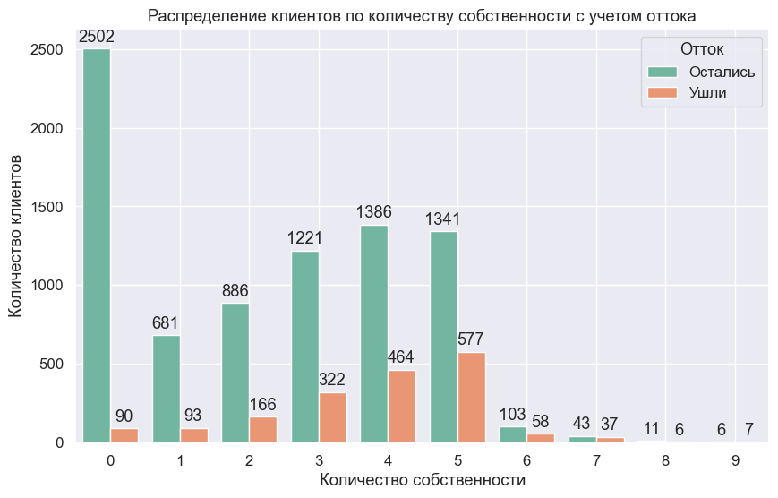

```python
# группировка данных по баллам собственности и оттоку
grouped_equity = data.groupby(['equity', 'churn']).size().reset_index(name='Количество клиентов')

# построение столбчатой диаграммы
plt.figure(figsize=(10, 6))
barplot = sns.barplot(x='equity', y='Количество клиентов', data=grouped_equity, hue='churn', dodge=True, palette='Set2')

# добавление подписей на столбцы
for p in barplot.patches:
    barplot.annotate(format(p.get_height(), '.0f'),
                     (p.get_x() + p.get_width() / 2., p.get_height()),
                     ha='center', va='center',
                     xytext=(0, 9),
                     textcoords='offset points')

# настройка меток и заголовка
plt.xlabel('Количество собственности')
plt.ylabel('Количество клиентов')
plt.title('Распределение клиентов по количеству собственности с учетом оттока')
plt.grid(True)

# настройка легенды
handles, labels = barplot.get_legend_handles_labels()
new_labels = ['Остались', 'Ушли']
plt.legend(handles, new_labels, title='Отток', loc='upper right')
plt.show()
```

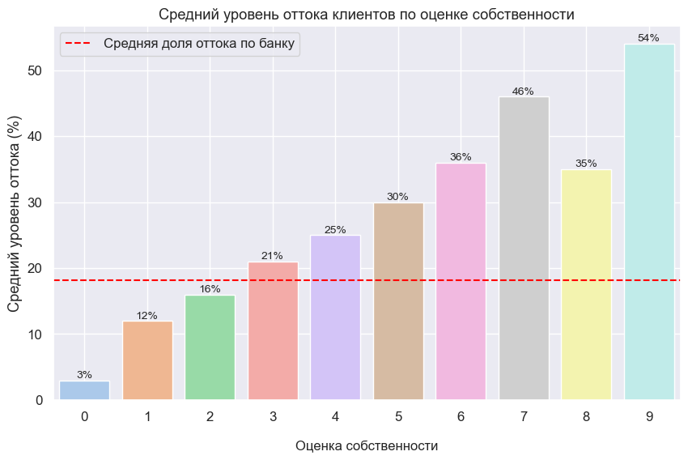

```python
# создание сводной таблицы с уровнем оттока по оценке собственности (equity)
equity_pivot = data.pivot_table(index='equity', values='churn', aggfunc='mean') * 100
equity_pivot = equity_pivot.round().astype(int)  # округляем до целых и преобразуем в int

# построение столбчатой диаграммы
plt.figure(figsize=(10, 6))
bar_plot = sns.barplot(x=equity_pivot.index, y=equity_pivot['churn'], palette='pastel')

# добавление подписей на столбцы
for p in bar_plot.patches:
    bar_plot.annotate(f"{int(p.get_height())}%",
                      (p.get_x() + p.get_width() / 2., p.get_height()),
                      ha='center', va='bottom',
                      fontsize=10)

# добавление линии для средней доли оттока по банку
plt.axhline(avg_churn, color='red', linestyle='--', label='Средняя доля оттока по банку')

# добавление легенды
plt.legend(loc='upper left')

# настройка графика
plt.title('Средний уровень оттока клиентов по оценке собственности')
plt.xlabel('Оценка собственности', fontsize=12, labelpad=15)
plt.ylabel('Средний уровень оттока (%)')
plt.grid(True)
plt.show()
```

**Анализ данных о клиентском оттоке в зависимости от уровня их оценки собственности**

**Клиенты без собственности (0):** Наименьший уровень оттока наблюдается среди клиентов, не имеющих собственности, с долей всего 3% (2592 клиента).

**Клиенты с небольшими активами (1–2):** У клиентов с одним активом (774 клиента) уровень оттока составляет 12%, а у клиентов с двумя активами (1052 клиента) — 16%. Это свидетельствует о том, что риск ухода увеличивается, но остается относительно низким.

**Клиенты с умеренными активами (3–4):** У клиентов с тремя активами (1543 клиента) уровень оттока достигает 21%, а у клиентов с четырьмя активами (1850 клиентов) он составляет 25%. В этой категории наблюдается заметный рост доли оттока.

**Клиенты с более высокими активами (5–6):** Клиенты с пятью активами (1918 клиентов) демонстрируют высокий уровень оттока на уровне 30%, а у клиентов с шестью активами (161 клиент) уровень оттока значительно увеличивается до 36%.

**Клиенты с самыми высокими активами (7–9):** Среди клиентов с семью активами (80 клиентов) уровень оттока составляет 46%, и у клиентов с девятью активами (13 клиентов) он достигает 54%. Эти показатели указывают на критический риск ухода среди клиентов с высоким уровнем собственности.

**Общий вывод:** Таким образом, наблюдается тенденция к увеличению уровня оттока клиентов с ростом оценки собственности. Несмотря на то, что клиенты с самой низкой оценкой собственности имеют наименьший риск ухода, клиенты с высокой оценкой активов становятся наиболее уязвимыми. Это может указывать на необходимость банка разработать стратегии удержания клиентов, особенно среди тех, кто обладает значительными активами.

#### Последняя активность (last_activity)

```python
# подсчет количества клиентов в зависимости от последней активности
la_counts = data['last_activity'].value_counts()
la_counts
```

```
last_activity
1    5235
0    4765
Name: count, dtype: int64
```

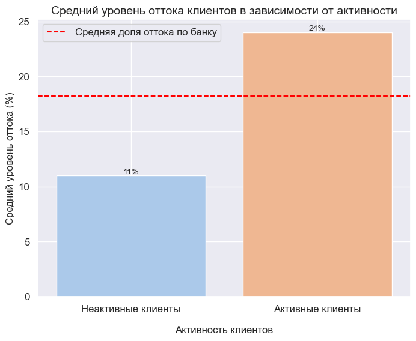

```python
# создание сводной таблицы с уровнем оттока по пользовательской активности
la_pivot = data.pivot_table(index='last_activity', values='churn', aggfunc='mean') * 100
la_pivot = la_pivot.round().astype(int)  # Округляем до целых и преобразуем в int

# построение столбчатой диаграммы
plt.figure(figsize=(8, 6))
bar_plot = sns.barplot(x=la_pivot.index, y=la_pivot['churn'], palette='pastel')

# добавление подписей на столбцы
for p in bar_plot.patches:
    bar_plot.annotate(f"{int(p.get_height())}%",
                      (p.get_x() + p.get_width() / 2., p.get_height()),
                      ha='center', va='bottom',
                      fontsize=10)

# настройка графика
plt.title('Средний уровень оттока клиентов в зависимости от активности', fontsize=14)
plt.xlabel('Активность клиентов', fontsize=12, labelpad=15)
plt.ylabel('Средний уровень оттока (%)', fontsize=12)

# добавление линии для средней доли оттока по банку
plt.axhline(avg_churn, color='red', linestyle='--', label='Средняя доля оттока по банку')

# добавление легенды
plt.legend(loc='upper left')

# скорректируем подписи по оси Х
bar_plot.set_xticklabels(['Неактивные клиенты', 'Активные клиенты'])

plt.grid(True)
plt.show()
```

**Вывод об уровне оттока клиентов по последней активности**

**Активные клиенты (last_activity = 1):** Среди активных клиентов, которые совершали действия недавно (5235 клиентов), уровень оттока составляет 24%. Этот показатель указывает на значительный риск ухода, несмотря на их недавнюю активность.

**Неактивные клиенты (last_activity = 0):** В то же время среди неактивных клиентов, которые не проявляют активности (4765 клиентов), уровень оттока составляет лишь 11%. Это может говорить о том, что клиенты, не вовлеченные в деятельность банка, менее подвержены уходу, возможно, из-за отсутствия стимулов к смене банка.

Таким образом, результаты показывают, что активные клиенты демонстрируют более высокий уровень оттока по сравнению с неактивными. Это может свидетельствовать о наличии проблем с удовлетворением потребностей активных клиентов или недостаточной лояльностью, что требует дополнительного внимания со стороны банка.

#### Пол (gender)

```python
# подсчёт количества женщин и мужчин среди клиентов
gender_counts = data['gender'].value_counts()
gender_counts
```

```
gender
М    5005
Ж    4995
Name: count, dtype: int64
```

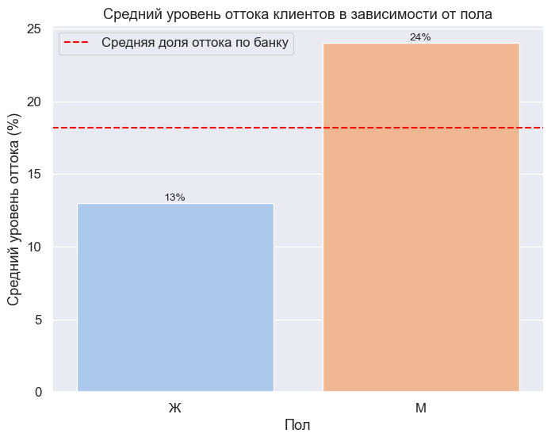

```python
# создание сводной таблицы с уровнем оттока по половому признаку
gender_pivot = data.pivot_table(index='gender', values='churn', aggfunc='mean') * 100
gender_pivot = gender_pivot.round().astype(int)  # округляем до целых и преобразуем в int

# построение столбчатой диаграммы
plt.figure(figsize=(8, 6))
bar_plot = sns.barplot(x=gender_pivot.index, y=gender_pivot['churn'], palette='pastel')

# добавление подписей на столбцы
for p in bar_plot.patches:
    bar_plot.annotate(f"{int(p.get_height())}%",
                      (p.get_x() + p.get_width() / 2., p.get_height()),
                      ha='center', va='bottom',
                      fontsize=10)

# добавление линии для средней доли оттока по банку
plt.axhline(avg_churn, color='red', linestyle='--', label='Средняя доля оттока по банку')

# добавление легенды
plt.legend(loc='upper left')

# настройка графика
plt.title('Средний уровень оттока клиентов в зависимости от пола')
plt.xlabel('Пол')
plt.ylabel('Средний уровень оттока (%)')
plt.show()
```

**Вывод об уровне оттока клиентов по полу**

**Мужчины (М):** Среди мужчин, составивших 5005 клиентов, уровень оттока составляет 24%. Это указывает на то, что мужчины проявляют значительную склонность к уходу.

**Женщины (Ж):** В группе женщин, насчитывающей 4995 клиентов, уровень оттока значительно ниже — всего 13%. Это говорит о более высокой степени лояльности среди женской аудитории.

Таким образом, данные показывают, что мужчины имеют гораздо более высокий риск ухода по сравнению с женщинами. Это может свидетельствовать о необходимости формирования специфических стратегий удержания для мужской части клиентской базы, направленных на улучшение удовлетворенности и лояльности.

#### Наличие кредитной карты (credit_card)

```python
# подсчёт количества клиентов с кредитной картой
card_counts = data['credit_card'].value_counts()
card_counts
```

```
credit_card
1    6804
0    3196
Name: count, dtype: int64
```

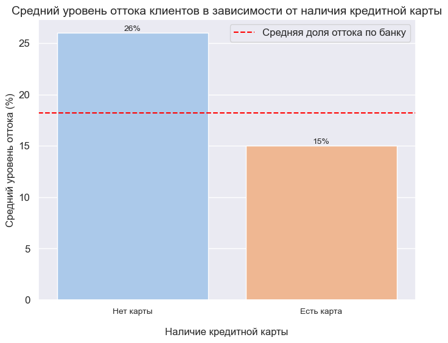

```python
# создание сводной таблицы с уровнем оттока по наличию кредитной карты
card_pivot = data.pivot_table(index='credit_card', values='churn', aggfunc='mean') * 100
card_pivot = card_pivot.round().astype(int)  # округляем до целых и преобразуем в int

# построение столбчатой диаграммы
plt.figure(figsize=(8, 6))
bar_plot = sns.barplot(x=card_pivot.index, y=card_pivot['churn'], palette='pastel')

# добавление подписей на столбцы
for p in bar_plot.patches:
    bar_plot.annotate(f"{int(p.get_height())}%",
                      (p.get_x() + p.get_width() / 2., p.get_height()),
                      ha='center', va='bottom',
                      fontsize=10)

# добавление линии для средней доли оттока по банку
plt.axhline(avg_churn, color='red', linestyle='--', label='Средняя доля оттока по банку')

# добавление легенды
plt.legend(loc='upper right')

# настройка графика
plt.title('Средний уровень оттока клиентов в зависимости от наличия кредитной карты', fontsize=14)
plt.xlabel('Наличие кредитной карты', fontsize=12, labelpad=15)
plt.ylabel('Средний уровень оттока (%)', fontsize=12)

# скорректируем подписи по оси Х
bar_plot.set_xticklabels(['Нет карты', 'Есть карта'], fontsize=10)

plt.show()
```

**Вывод об уровне оттока клиентов в зависимости от наличия кредитной карты**

**Клиенты с кредитной картой (1):** Среди клиентов, имеющих кредитные карты (6804 клиента), уровень оттока составляет 15%. Это указывает на относительно низкий риск ухода в этой группе.

**Клиенты без кредитной карты (0):** В то же время клиенты, не имеющие кредитных карт (3196 клиентов), демонстрируют более высокий уровень оттока — 26%.

Таким образом, результаты анализа показывают, что клиенты без кредитной карты имеют гораздо более высокий риск оттока по сравнению с теми, кто имеет кредитную карту. Это может свидетельствовать о том, что наличие кредитной карты играет важную роль в удержании клиентов. Рекомендуется рассмотреть возможность предложения кредитных карт клиентам, которые их не имеют, а также разработать стратегии, направленные на улучшение удовлетворенности и лояльности данной группы клиентов.

#### Город (city)

```python
# подсчёт количества клиентов в каждом городе
city_counts = data['city'].value_counts()
city_counts
```

```
city
Ярославль    5888
Рыбинск      2695
Ростов       1417
Name: count, dtype: int64
```

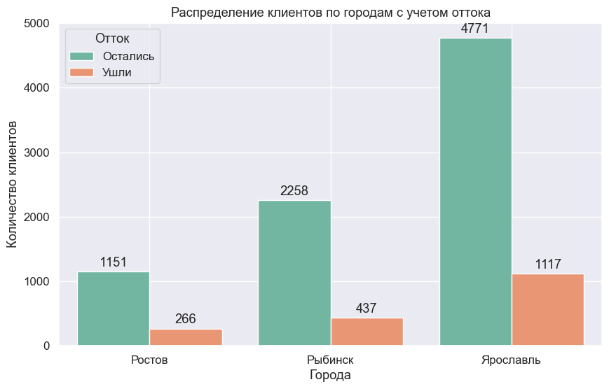

```python
# группировка данных по городам и оттоку
grouped_city = data.groupby(['city', 'churn']).size().reset_index(name='Количество клиентов')

# построение столбчатой диаграммы
plt.figure(figsize=(10, 6))
barplot = sns.barplot(x='city', y='Количество клиентов', data=grouped_city, hue='churn', dodge=True, palette='Set2')

# добавление подписей на столбцы
for p in barplot.patches:
    barplot.annotate(format(p.get_height(), '.0f'),
                     (p.get_x() + p.get_width() / 2., p.get_height()),
                     ha='center', va='center',
                     xytext=(0, 9),  # Смещение текста
                     textcoords='offset points')

# настройка меток и заголовка
plt.xlabel('Города')
plt.ylabel('Количество клиентов')
plt.title('Распределение клиентов по городам с учетом оттока')
plt.grid(True)

# настройка легенды
handles, labels = barplot.get_legend_handles_labels()
new_labels = ['Остались', 'Ушли']
plt.legend(handles, new_labels, title='Отток', loc='upper left')
plt.show()
```

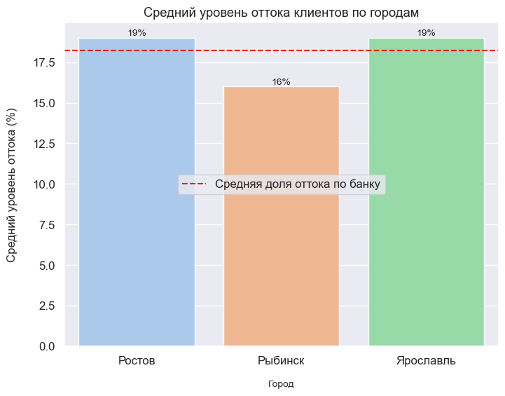

```python
# создание сводной таблицы с уровнем оттока по городу
city_pivot = data.pivot_table(index='city', values='churn', aggfunc='mean') * 100
city_pivot = city_pivot.round().astype(int)  # округляем до целых и преобразуем в int

# построение столбчатой диаграммы
plt.figure(figsize=(8, 6))
bar_plot = sns.barplot(x=city_pivot.index, y=city_pivot['churn'], palette='pastel')

# добавление подписей на столбцы
for p in bar_plot.patches:
    bar_plot.annotate(f"{int(p.get_height())}%",
                      (p.get_x() + p.get_width() / 2., p.get_height()),
                      ha='center', va='bottom',
                      fontsize=10)

# добавление линии для средней доли оттока по банку
plt.axhline(avg_churn, color='red', linestyle='--', label='Средняя доля оттока по банку')

# добавление легенды
plt.legend(loc='center')

# настройка графика
plt.title('Средний уровень оттока клиентов по городам')
plt.xlabel('Город', fontsize=10, labelpad=15)
plt.ylabel('Средний уровень оттока (%)', fontsize=12, labelpad=15)
plt.show()
```

**Вывод об уровне оттока клиентов по городам**

**Ярославль:** Из 5888 клиентов в Ярославле уровень оттока составляет 19%, что эквивалентно 1117 ушедшим клиентам. Остались 4771 клиент.

**Рыбинск:** В Рыбинске из 2695 клиентов уровень оттока ниже — 16%. Здесь ушли 437 клиентов, а остались 2258.

**Ростов:** В Ростове уровень оттока также составляет 19% из 1417 клиентов, что означает уход 266 клиентов, при этом осталось 1151 клиент.

Таким образом, можно сделать вывод, что этот показатель варьируется незначительно. Города Ростов и Ярославль демонстрируют схожий уровень оттока на уровне 19%, в то время как в Рыбинске он составляет 16%. Эти результаты позволяют предположить, что географическое расположение клиентов в городах не оказывает значительного влияния на их склонность к оттоку. Кроме того, учитывая близость уровней оттока, возможно, существует схожесть в факторах, влияющих на удовлетворенность клиентов в этих городах.

### Сравнение портретов клиентов

Произведём вычисление средних и медианных значений ключевых показателей для групп клиентов по признаку оттока.

```python
df = pd.DataFrame(data)

# сегментация по оттоку
segment_1 = df[df['churn'] == 0]  # Не ушли
segment_2 = df[df['churn'] == 1]  # Ушли

# функция для расчета мер центральной тенденции
def calculate_central_tendency(segment):
    continuous_features = ['score', 'age', 'equity', 'balance', 'last_activity', 'est_salary']
    discrete_features = ['products']
    categorical_features = ['city', 'gender', 'credit_card']

    mean_values = segment[continuous_features].mean()
    median_values = segment[continuous_features].median()
    median_discrete = segment[discrete_features].median()
    mode_categorical = segment[categorical_features].mode().iloc[0]

    return mean_values, median_values, median_discrete, mode_categorical

mean_1, median_1, median_discrete_1, mode_1 = calculate_central_tendency(segment_1)
mean_2, median_2, median_discrete_2, mode_2 = calculate_central_tendency(segment_2)

# относительная разница между медианой и средним для непрерывных признаков
relative_difference_1 = (median_1 - mean_1) / mean_1
relative_difference_2 = (median_2 - mean_2) / mean_2

# формирование таблицы с переименованными столбцами
summary = pd.DataFrame({
    'Признак': ['score', 'age', 'equity', 'balance', 'last_activity', 'est_salary', 'products', 'city', 'gender', 'credit_card'],
    'Не ушли среднее': [mean_1['score'], mean_1['age'], mean_1['equity'], mean_1['balance'], mean_1['last_activity'], mean_1['est_salary'], np.nan, np.nan, np.nan, np.nan],
    'Не ушли медиана': [median_1['score'], median_1['age'], median_1['equity'], median_1['balance'], median_1['last_activity'], median_1['est_salary'], median_discrete_1['products'], np.nan, np.nan, np.nan],
    'Не ушли мода': [np.nan, np.nan, np.nan, np.nan, np.nan, np.nan, np.nan, mode_1['city'], mode_1['gender'], mode_1['credit_card']],
    'Ушли среднее': [mean_2['score'], mean_2['age'], mean_2['equity'], mean_2['balance'], mean_2['last_activity'], mean_2['est_salary'], np.nan, np.nan, np.nan, np.nan],
    'Ушли медиана': [median_2['score'], median_2['age'], median_2['equity'], median_2['balance'], median_2['last_activity'], median_2['est_salary'], median_discrete_2['products'], np.nan, np.nan, np.nan],
    'Ушли мода': [np.nan, np.nan, np.nan, np.nan, np.nan, np.nan, np.nan, mode_2['city'], mode_2['gender'], mode_2['credit_card']],
    'Отн. разница (Медиана к Среднему) Не ушли': [relative_difference_1['score'], relative_difference_1['age'], relative_difference_1['equity'], relative_difference_1['balance'], relative_difference_1['last_activity'], relative_difference_1['est_salary'], np.nan, np.nan, np.nan, np.nan],
    'Отн. разница (Медиана к Среднему) Ушли': [relative_difference_2['score'], relative_difference_2['age'], relative_difference_2['equity'], relative_difference_2['balance'], relative_difference_2['last_activity'], relative_difference_2['est_salary'], np.nan, np.nan, np.nan, np.nan],
})

# замена NaN на "Нет данных" для категориальных признаков и на 0 для числовых признаков
summary[['Не ушли среднее', 'Не ушли медиана', 'Ушли среднее', 'Ушли медиана', 'Отн. разница (Медиана к Среднему) Не ушли', 'Отн. разница (Медиана к Среднему) Ушли']] = summary[['Не ушли среднее', 'Не ушли медиана', 'Ушли среднее', 'Ушли медиана', 'Отн. разница (Медиана к Среднему) Не ушли', 'Отн. разница (Медиана к Среднему) Ушли']].fillna(0)
summary[['Не ушли мода', 'Ушли мода']] = summary[['Не ушли мода', 'Ушли мода']].fillna('Нет данных')

display(summary)
```

|  | Признак | Не ушли среднее | Не ушли медиана | Не ушли мода | Ушли среднее | Ушли медиана | Ушли мода | Отн. разница (Медиана к Среднему) Не ушли | Отн. разница (Медиана к Среднему) Ушли |
| --- | --- | --- | --- | --- | --- | --- | --- | --- | --- |
| 0 | score | 845.43 | 848.00 | Нет данных | 863.40 | 866.00 | Нет данных | 0.00 | 0.00 |
| 1 | age | 43.01 | 40.00 | Нет данных | 41.45 | 39.00 | Нет данных | -0.07 | -0.06 |
| 2 | equity | 2.37 | 3.00 | Нет данных | 3.76 | 4.00 | Нет данных | 0.26 | 0.06 |
| 3 | balance | 733982.59 | 475382.45 | Нет данных | 1133993.27 | 782410.47 | Нет данных | -0.35 | -0.31 |
| 4 | last_activity | 0.48 | 0.00 | Нет данных | 0.70 | 1.00 | Нет данных | -1.00 | 0.42 |
| 5 | est_salary | 147783.20 | 118257.71 | Нет данных | 148243.01 | 125390.62 | Нет данных | -0.20 | -0.15 |
| 6 | products | 0.00 | 2.00 | Нет данных | 0.00 | 2.00 | Нет данных | 0.00 | 0.00 |
| 7 | city | 0.00 | 0.00 | Ярославль | 0.00 | 0.00 | Ярославль | 0.00 | 0.00 |
| 8 | gender | 0.00 | 0.00 | Ж | 0.00 | 0.00 | М | 0.00 | 0.00 |
| 9 | credit_card | 0.00 | 0.00 | 1 | 0.00 | 0.00 | 1 | 0.00 | 0.00 |

**Портреты клиентов**

На основании полученных данных можно выделить два основных портрета клиентов: **клиенты, остающиеся в банке** и **клиенты, уходящие из банка**:

1. Клиенты, остающиеся в банке:
- **Баллы скоринга:** Средний скоринговый балл составляет 845.43, медиана (848.00) подтверждает, что большая часть клиентов имеет стабильные и хорошие кредитные оценки.Средний балл (score): 845.43. Этот показатель указывает на высокую кредитоспособность и доверие к клиентам.
- **Возраст:** Средний возраст составляет 43 года, медиана 40 лет. Средний возраст клиентов указывает на зрелую аудиторию, которая, вероятно, обладает стабильным доходом и финансовой ситуацией.
- **Баллы собственности:** Средний кол-во объектов собственности 2.37, медиана 3.00
- **Баланс на счете:** Средний баланс 733982.59 руб, медиана 475382.45 руб. Разница между средним и медианным балансом показывает, что у некоторых клиентов есть очень крупные счета, хотя большинство имеет средний уровень сбережений.
- **Активность:** Средняя активность 0.48, медиана 0.00. Низкий уровень активности может говорить о том, что клиенты довольны своими текущими услугами и не предпринимают дополнительных действий.
- **Зарплата:** Средняя зарплата клиентов — 147 783.20 руб., медиана 118 257.71 руб. Высокий уровень дохода подтверждает, что клиенты имеют хорошую платежеспособность.
- **Количество продуктов:** Медиана - 2. Использование двух продуктов или услуг компании указывает на удовлетворенность клиентов предложениями компании.
- **Город:** Мода - Ярославль. Ярославль как основной город проживания указывает на географическую концентрацию клиентов.
- **Пол:** Мода - Женщины. Преобладание женщин может указывать на то, что эта группа клиентов больше удовлетворена предлагаемыми услугами.
- **Использование кредитных карт:** Мода - 1. Наличие кредитной карты у большинства клиентов подтверждает их активное использование банковских продуктов.

**Выводы:** Клиенты, которые остались в банке, представляют собой зрелую и финансово стабильную группу. Эти клиенты имеют разнообразные источники дохода.

2. Клиенты, уходящие из банка
- **Баллы скоринга:** Средний скоринговый балл составляет 863.40, медиана - 866. Высокий кредитный балл указывает на то, что эти клиенты также были надежными и платежеспособными, однако это не гарантирует лояльности к конкретной компании.
- **Возраст:** Средний возраст 41.45 года, медиана 39 лет. Клиенты, которые ушли, немного моложе, что может говорить о большей склонности к переменам и поиску новых условий.
- **Баллы собственности:** Средний кол-во объектов собственности 3.76, медиана 4.00.
- **Баланс на счете:** Средний баланс 1 133 993.27 руб, медиана 782 410.47 руб. Высокие средний и медианный баланс указывают на то, что клиенты с крупными счетами чаще покидают компанию, возможно, в поисках более выгодных условий.
- **Активность:** Средняя активность 0.70, медиана 1.00. Более высокая активность может свидетельствовать о том, что клиенты пытались решить проблемы или изменять условия, но в итоге решили уйти.
- **Зарплата:** Средняя зарплата клиентов — 148 243.01 руб., медиана 125 390.62 руб. Эти клиенты имели чуть более высокий уровень дохода, чем оставшиеся.
- **Количество продуктов:** Медиана - 2. Использование двух продуктов или услуг компании также характерно для этой группы, но это не удержало их от ухода.
- **Город:** Мода - Ярославль. Как и у клиентов, которые остались, большинство ушедших проживает в Ярославле.
- **Пол:** Мода - Мужчины. Преобладание мужчин может указывать на то, что эта группа клиентов менее удовлетворена предлагаемыми услугами или более активно ищет лучшие условия.
- **Использование кредитных карт:** Мода - 1. Большинство клиентов имели кредитную карту, что указывает на активное использование банковских продуктов перед уходом.

**Выводы:** Уходящие клиенты склонны к поиску лучших предложений и имеют более широкий выбор продуктов, что может быть связано с их активной позицией на рынке финансовых услуг.

Анализ портретов клиентов показывает, что остающиеся клиенты более привержены к банку, обладают достаточным уровнем финансовой стабильности и предпочитают простоту в продуктах. В то время как уходящие клиенты имеют более разнообразный опыт использования финансовых продуктов и ищут оптимальные условия, что делает их менее лояльными к конкретному банку. Рекомендуется учитывать эти особенности при разработке стратегий удержания клиентов.

Интересно отметить, что признак активности показывает обратную тенденцию: для не ушедших клиентов медианное значение активности значительно ниже среднего, что свидетельствует о невысокой активности, тогда как для ушедших клиентов медиана превышает среднее на 42%. Это может указывать на повышенную активность перед их уходом.

### Статистический анализ данных

#### Гипотеза №1. О различии дохода между клиентами, склонных и не склонных к оттоку

Сформулируем первую гипотезу:

- **Нулевая гипотеза (H0):** Средний доход ушедших клиентов равен среднему доходу оставшихся клиентов.
- **Альтернативная гипотеза (H1):** Средний доход ушедших клиентов отличается от среднего дохода оставшихся клиентов.

Необходимо выбрать критерий проведения теста.

Например, для корректного проведения `t-критерия Стьюдента` необходимо соблюдение определенных требований:

- Данные должны быть нормально распределены.
- Дисперсии обеих групп должны быть равны.
- Данные не должны содержать значительных выбросов, которые могут искажать результаты анализа.
- Наблюдения в каждой выборке должны быть независимы друг от друга
- Набор данных должен быть достаточно велик (обычно n > 30).

Проведем тесты для определения, соответствуют ли данные в датасете этим критериям.

Для проверки нормальности распределения данных и выбора статистического теста проведем тест на нормальность, например, `тест Шапиро-Уилка`.

```python
# извлечение доходов для клиентов, склонных к оттоку и не склонных
income_churned = data[data['churn'] == 1]['est_salary'].values  # клиенты, склонные к оттоку
income_not_churned = data[data['churn'] == 0]['est_salary'].values  # клиенты, не склонные к оттоку

# применение теста Шапиро-Уилка
stat_churned, p_churned = st.shapiro(income_churned)
stat_not_churned, p_not_churned = st.shapiro(income_not_churned)

# вывод результатов
print('Результаты теста Шапиро-Уилка для клиентов, склонных к оттоку:')
print('Статистика = %.3f, p-значение = %.8f' % (stat_churned, p_churned))

print('Результаты теста Шапиро-Уилка для клиентов, не склонных к оттоку:')
print('Статистика = %.3f, p-значение = %.8f' % (stat_not_churned, p_not_churned))

# получение результатов
alpha = 0.05
if p_churned > alpha:
    print("Нет оснований отвергать нулевую гипотезу (данные нормально распределены) для клиентов, склонных к оттоку.")
else:
    print("Отвергаем нулевую гипотезу (данные не нормально распределены) для клиентов, склонных к оттоку.")

if p_not_churned > alpha:
    print("Нет оснований отвергать нулевую гипотезу (данные нормально распределены) для клиентов, не склонных к оттоку.")
else:
    print("Отвергаем нулевую гипотезу (данные не нормально распределены) для клиентов, не склонных к оттоку.")
```

```
Результаты теста Шапиро-Уилка для клиентов, склонных к оттоку:
Статистика = 0.644, p-значение = 0.00000000
Результаты теста Шапиро-Уилка для клиентов, не склонных к оттоку:
Статистика = 0.615, p-значение = 0.00000000
Отвергаем нулевую гипотезу (данные не нормально распределены) для клиентов, склонных к оттоку.
Отвергаем нулевую гипотезу (данные не нормально распределены) для клиентов, не склонных к оттоку.
```

```python
# тест на равенство дисперсий
stat_levene, p_levene = st.levene(income_churned, income_not_churned)

# вывод результатов
print('Статистика теста Левене = %.3f' % stat_levene)
print('p-значение теста Левене = %.8f' % p_levene)

# интерпретация
alpha = 0.05
if p_levene < alpha:
    print("Отвергаем нулевую гипотезу: дисперсии выборок статистически различаются.")
else:
    print("Нет оснований отвергать нулевую гипотезу: дисперсии выборок равны.")
```

```
Статистика теста Левене = 6.725
p-значение теста Левене = 0.00952072
Отвергаем нулевую гипотезу: дисперсии выборок статистически различаются.
```

Результаты теста Шапиро-Уилка показывают, что данные по доходам для обеих групп клиентов не нормально распределены, так как p-значения значительно меньше уровня значимости α=0.05. Результаты теста Левене показывают неравенство дисперсий.

В таком случае, когда данные не подчиняются нормальному распределению, а дисперсии неравны, использование t-критерия Стьюдента может привести к неверным выводам.  
Будем использовать непараметрический тест для сравнения доходов между двумя группами - `тест Манна-Уитни`.

```python
# применение теста Манна-Уитни
stat, p = st.mannwhitneyu(income_churned, income_not_churned)

# вывод результатов
print('Результаты теста Манна-Уитни:')
print('Статистика = %.3f, p-значение = %.3f' % (stat, p))

# интерпретация результатов
alpha = 0.05
if p > alpha:
    print("Нет оснований отвергать нулевую гипотезу (нет значимых различий между доходами двух групп).")
else:
    print("Отвергаем нулевую гипотезу (существуют значимые различия между доходами двух групп).")
```

```
Результаты теста Манна-Уитни:
Статистика = 7852481.000, p-значение = 0.000
Отвергаем нулевую гипотезу (существуют значимые различия между доходами двух групп).
```

Полученные результаты теста Манна-Уитни показывают, доходы клиентов, склонных к оттоку, статистически значимо отличаются от доходов клиентов, не склонных к оттоку. В ходе исследовательского анализа было установлено, что клиенты, находящиеся в состоянии оттока, более финансово обеспечены.

#### Гипотеза №2. Использование продуктов банка

- **Нулевая гипотеза (H0):** Количество банковских продуктов, используемых ушедшими и оставшимися клиентами равно.
- **Альтернативная гипотеза (H1):** Количество банковских продуктов, используемых ушедшими и оставшимися клиентами не равно.

Для проверки нормальности распределения данных и выбора статистического теста проведем тест на нормальность, например, тест Шапиро-Уилка.

```python
# извлечение продуктов для клиентов, склонных к оттоку и не склонных
products_churned = data[data['churn'] == 1]['products'].values  # клиенты, склонные к оттоку
products_not_churned = data[data['churn'] == 0]['products'].values  # клиенты, не склонные к оттоку

# применение теста Шапиро-Уилка
stat_churned, p_churned = st.shapiro(products_churned)
stat_not_churned, p_not_churned = st.shapiro(products_not_churned)

# вывод результатов
print('Результаты теста Шапиро-Уилка для клиентов, склонных к оттоку:')
print('Статистика = %.3f, p-значение = %.8f' % (stat_churned, p_churned))

print('Результаты теста Шапиро-Уилка для клиентов, не склонных к оттоку:')
print('Статистика = %.3f, p-значение = %.8f' % (stat_not_churned, p_not_churned))

# получение результатов
alpha = 0.05
if p_churned > alpha:
    print("Нет оснований отвергать нулевую гипотезу (данные нормально распределены) для клиентов, склонных к оттоку.")
else:
    print("Отвергаем нулевую гипотезу (данные не нормально распределены) для клиентов, склонных к оттоку.")

if p_not_churned > alpha:
    print("Нет оснований отвергать нулевую гипотезу (данные нормально распределены) для клиентов, не склонных к оттоку.")
else:
    print("Отвергаем нулевую гипотезу (данные не нормально распределены) для клиентов, не склонных к оттоку.")
```

```
Результаты теста Шапиро-Уилка для клиентов, склонных к оттоку:
Статистика = 0.829, p-значение = 0.00000000
Результаты теста Шапиро-Уилка для клиентов, не склонных к оттоку:
Статистика = 0.782, p-значение = 0.00000000
Отвергаем нулевую гипотезу (данные не нормально распределены) для клиентов, склонных к оттоку.
Отвергаем нулевую гипотезу (данные не нормально распределены) для клиентов, не склонных к оттоку.
```

```python
# Применение теста Манна-Уитни
u_statistic, p_value = st.mannwhitneyu(products_churned, products_not_churned, alternative='two-sided')

# Вывод результатов теста Манна-Уитни
print('Результаты теста Манна-Уитни:')
print('Статистика =', u_statistic, ', p-значение =', p_value)

# Получение результатов
if p_value < alpha:
    print("Отвергаем нулевую гипотезу (различия между группами статистически значимы).")
else:
    print("Нет оснований отвергать нулевую гипотезу (различия между группами не статистически значимы).")
```

```
Результаты теста Манна-Уитни:
Статистика = 10191562.5 , p-значение = 4.3792410512214974e-162
Отвергаем нулевую гипотезу (различия между группами статистически значимы).
```

Различия в использовании банковских продуктов между клиентами, склонными к оттоку, и клиентами, не склонными к оттоку, являются статистически значимыми. В ходе исследовательского анализа было установлено, что клиенты, находящиеся в состоянии оттока, используют большее количество банковских продуктов.

#### Гипотеза №3. Активность клиента

- **Нулевая гипотеза (H0):** Количество активных клиентов, склонных к оттоку, равно количеству неактивных клиентов, склонных к оттоку.
- **Альтернативная гипотеза (H1):** Количество активных клиентов, склонных к оттоку, не равно количеству неактивных клиентов, склонных к оттоку.

```python
# извлечение данных для клиентов, склонных к оттоку и не склонных
la_churned = data[data['churn'] == 1]['last_activity'].values  # клиенты, склонные к оттоку
la_not_churned = data[data['churn'] == 0]['last_activity'].values  # клиенты, не склонные к оттоку

# применение теста Шапиро-Уилка
stat_churned, p_churned = st.shapiro(la_churned)
stat_not_churned, p_not_churned = st.shapiro(la_not_churned)

# вывод результатов
print('Результаты теста Шапиро-Уилка для клиентов, склонных к оттоку:')
print('Статистика = %.3f, p-значение = %.8f' % (stat_churned, p_churned))

print('Результаты теста Шапиро-Уилка для клиентов, не склонных к оттоку:')
print('Статистика = %.3f, p-значение = %.8f' % (stat_not_churned, p_not_churned))

# получение результатов
alpha = 0.05
if p_churned > alpha:
    print("Нет оснований отвергать нулевую гипотезу (данные нормально распределены) для клиентов, склонных к оттоку.")
else:
    print("Отвергаем нулевую гипотезу (данные не нормально распределены) для клиентов, склонных к оттоку.")

if p_not_churned > alpha:
    print("Нет оснований отвергать нулевую гипотезу (данные нормально распределены) для клиентов, не склонных к оттоку.")
else:
    print("Отвергаем нулевую гипотезу (данные не нормально распределены) для клиентов, не склонных к оттоку.")
```

```
Результаты теста Шапиро-Уилка для клиентов, склонных к оттоку:
Статистика = 0.574, p-значение = 0.00000000
Результаты теста Шапиро-Уилка для клиентов, не склонных к оттоку:
Статистика = 0.636, p-значение = 0.00000000
Отвергаем нулевую гипотезу (данные не нормально распределены) для клиентов, склонных к оттоку.
Отвергаем нулевую гипотезу (данные не нормально распределены) для клиентов, не склонных к оттоку.
```

В дополнение к тесту Манна-Уитни проведем Z-тест для проверки гипотезы о равенстве пропорций. Этот тест подходит для анализа различий в долях клиентов, склонных к оттоку, и особенно эффективен при работе с большими выборками.

```python
# Z-тест
# количество наблюдений с положительным результатом в каждой группе
successes = [la_churned.sum(), la_not_churned.sum()]

# общее количество наблюдений в каждой группе
nobs = [len(la_churned), len(la_not_churned)]

# выполнение z-теста для пропорций
z_stat, p_value = sm.stats.proportions_ztest(successes, nobs)

print('Z-тест для пропорций:')
print('Статистика z =', z_stat, ', p-значение =', p_value)

# получение результатов
alpha = 0.05
if p_value < alpha:
    print("Отвергаем нулевую гипотезу (пропорции различаются между группами).")
else:
    print("Нет оснований отвергать нулевую гипотезу (пропорции не различаются между группами).")
```

```
Z-тест для пропорций:
Статистика z = 16.876736037699324 , p-значение = 6.673391534618566e-64
Отвергаем нулевую гипотезу (пропорции различаются между группами).
```

```python
# применение теста Манна-Уитни
u_statistic, p_value = st.mannwhitneyu(la_churned, la_not_churned, alternative='two-sided')

# вывод результатов теста Манна-Уитни
print('Результаты теста Манна-Уитни:')
print('Статистика =', u_statistic, ', p-значение =', p_value)

# получение результатов
if p_value < alpha:
    print("Отвергаем нулевую гипотезу (различия между группами статистически значимы).")
else:
    print("Нет оснований отвергать нулевую гипотезу (различия между группами не статистически значимы).")
```

```
Результаты теста Манна-Уитни:
Статистика = 9069950.0 , p-значение = 6.770039678399235e-64
Отвергаем нулевую гипотезу (различия между группами статистически значимы).
```

Результаты проведенных тестов (Z-тест для пропорций и тест Манна-Уитни) показали статистически значимые различия между группами клиентов. В ходе исследовательского анализа также было установлено, что доля активных клиентов среди отточных клиентов выше, чем среди неактивных клиентов, они не равны.

#### Гипотеза №4. Пол клиента

- **Нулевая гипотеза (H0):** Доля ушедших мужчин равна доле ушедших женщин.
- **Альтернативная гипотеза (H1):** Доля ушедших мужчин отличается от доли ушедших женщин.

В дополнение к тесту Манна-Уитни проведем Z-тест для проверки гипотезы о равенстве пропорций. Этот тест подходит для анализа различий в долях мужчин и женщин, склонных к оттоку, и особенно эффективен при работе с большими выборками.

```python
# извлечение данных о поле клиентов, склонных к оттоку и не склонных
gender_churned = data[data['churn'] == 1]['Пол'].values  # клиенты, склонные к оттоку
gender_not_churned = data[data['churn'] == 0]['Пол'].values  # клиенты, не склонные к оттоку

# количество наблюдений с положительным результатом в каждой группе
successes = [gender_churned.sum(), gender_not_churned.sum()]

# общее количество наблюдений в каждой группе
nobs = [len(gender_churned), len(gender_not_churned)]

# выполнение z-теста для пропорций
z_stat, p_value = sm.stats.proportions_ztest(successes, nobs)

print('Z-тест для пропорций:')
print('Статистика z =', z_stat, ', p-значение =', p_value)

# получение результатов
alpha = 0.05
if p_value < alpha:
    print("Отвергаем нулевую гипотезу (пропорции различаются между группами).")
else:
    print("Нет оснований отвергать нулевую гипотезу (пропорции не различаются между группами).")

# проведение теста Манна-Уитни
u_statistic, p_mannwhitney = st.mannwhitneyu(gender_churned, gender_not_churned, alternative='two-sided')

# вывод результатов теста Манна-Уитни
print('Тест Манна-Уитни:')
print('Статистика U =', u_statistic, ', p-значение =', p_mannwhitney)

# получение результатов теста Манна-Уитни
if p_mannwhitney < alpha:
    print("Отвергаем нулевую гипотезу (различия между группами статистически значимы).")
else:
    print("Нет оснований отвергать нулевую гипотезу (различия между группами не статистически значимы).")
```

```
Z-тест для пропорций:
Статистика z = 14.103615114684509 , p-значение = 3.608027945045774e-45
Отвергаем нулевую гипотезу (пропорции различаются между группами).
Тест Манна-Уитни:
Статистика U = 8804250.0 , p-значение = 3.6445391323158074e-45
Отвергаем нулевую гипотезу (различия между группами статистически значимы).
```

**Z-тест:** Нулевая гипотеза была отвергнута, что указывает на статистически значимые различия в пропорциях клиентов, склонных к оттоку, по сравнению с теми, кто не склонен.

**Тест Манна-Уитни:** Этот тест также выявил статистически значимые различия между двумя группами, что свидетельствует о том, что распределения характеристик клиентов по полу отличаются.

В дополнение, в ходе исследовательского анализа было установлено, что доля мужчин среди клиентов, склонных к оттоку, выше, чем доля женщин.

#### Вывод по разделу

В рамках проведенного исследования были проанализированы данные клиентов, склонных к оттоку, и тех, кто не демонстрирует такую склонность.

**Распределение данных:**

Результаты теста Шапиро-Уилка показали, что данные по доходам для обеих групп клиентов не подчиняются нормальному распределению: Для клиентов, склонных к оттоку, статистика составила 0.644 с p-значением = 0.00000000. Для клиентов, не склонных к оттоку, статистика равнялась 0.615 с p-значением = 0.00000000. Поскольку нулевая гипотеза о нормальности распределения была отвергнута для обеих групп, было принято решение использовать непараметрический тест Манна-Уитни для дальнейшего анализа.

**Сравнение доходов:**

Результаты теста Манна-Уитни указали на статистически значимые различия в доходах между двумя группами: статистика = 7852481.000, p-значение = 0.000. Это говорит о том, что клиенты, склонные к оттоку, имеют более высокий уровень финансового обеспечения по сравнению с теми, кто не склонен к оттоку.

**Использование банковских продуктов:**

Аналогично, тест Манна-Уитни выявил значимые различия в использовании банковских продуктов: статистика = 10191562.5, p-значение < 0.0001. Это показывает, что клиенты, находящиеся в состоянии оттока, пользуются большим количеством банковских услуг по сравнению с клиентами, которые не проявляют склонности к оттоку.

**Пропорции активных клиентов:**

Проведенные Z-тесты для пропорций также подтвердили наличие статистически значимых различий между группами клиентов. В частности, обе группы показывают различия в активной клиентской базе, где доля активных клиентов среди склонных к оттоку выше, чем у тех, кто не склонен к оттоку (Z = 16.88, p < 0.0001).

**Половые различия:**

Анализ показал, что среди клиентов, склонных к оттоку, выше доля мужчин по сравнению с женщинами, что может свидетельствовать о различных потребительских предпочтениях и поведении по полу.

Полученные результаты подтверждают наличие статистически значимых различий между клиентами, склонными к оттоку, и теми, кто не склонен к оттоку, как по уровню доходов, так и по использованию банковских продуктов.

### Промежуточный вывод

Промежуточные итоги анализа клиентских характеристик

1. Количество продуктов (products)
- **Результат сравнения портретов**: Клиенты с одним продуктом имеют самый низкий уровень оттока (7%), что указывает на высокую лояльность. С увеличением числа продуктов до четырех, уровень оттока возрастает до 63%.
- **Результат анализа корреляций**: Наблюдается положительная корреляция (0.44) между количеством продуктов и уровнем оттока, что подтверждает значимость этого показателя для прогнозирования ухода клиентов.
- **Интерпретация графиков**: Гистограмма и анализ долей оттока показывают, что клиенты с более чем тремя продуктами имеют повышенный риск ухода.
- **Вердикт**: Количество продуктов является важным признаком для построения сегментов клиентов. Будем использовать этот признак для дальнейшего анализа и разработки стратегий удержания.
2. Оценка собственности (equity)
- **Результат сравнения портретов**: У клиентов с семью объектами уровень оттока составляет 46%, а с девятью — 54%. У клиентов без собственности уровень оттока равен 3%.
- **Результат анализа корреляций**: Прослеживается положительная корреляция (0.35) между оценкой собственности и оттоком, что указывает на прямую зависимость: чем больше объектов у клиента, тем выше вероятность ухода.
- **Интерпретация графиков**: Гистограмма показывает, что клиенты с высокой оценкой собственности имеют более высокий уровень оттока.
- **Вердикт**: Оценка собственности является важным признаком для сегментации клиентов и разработки персонализированных стратегий удержания.
3. Пол (gender)
- **Результат сравнения портретов**: Мужчины демонстрируют более высокий уровень оттока (24%) по сравнению с женщинами (13%).
- **Результат анализа корреляций**: Пол клиентов имеет небольшую положительную корреляцию (0.22) с оттоком, что указывает на некоторое влияние на вероятность ухода.
- **Интерпретация графиков**: Распределение оттока по полу показывает, что мужчины чаще покидают банк.
- **Вердикт**: Пол клиентов не является ключевым признаком для построения сегментов с высоким уровнем оттока, но будет учтен в общей стратегии удержания.
4. Возрастные интервалы
- **Результат сравнения портретов**: Заметные всплески оттока наблюдаются среди клиентов в возрасте 25-35 лет и около 48-60 лет.
- **Результат анализа корреляций**: Возраст имеет небольшую положительную корреляцию (0.19) с оттоком, указывая на его влияние на вероятность ухода.
- **Интерпретация графиков**: Графики оттока по возрастным группам подтверждают выявленные всплески.
- **Вердикт**: Возрастные интервалы являются важным критерием для сегментации клиентов с высоким уровнем оттока и будут использованы для дальнейшего анализа и разработки стратегий удержания.
5. Баланс на счете (balance)
- **Результат сравнения портретов**: Клиенты с более высокими балансами чаще склонны к оттоку, что может быть связано с более высокими финансовыми ожиданиями или другими причинами.
- **Результат анализа корреляций**: Данные о корреляциях пока отсутствуют.
- **Интерпретация графиков**: Распределение показывает, что большинство клиентов имеют балансы до 500 000 руб., а клиенты, имеющие баланс от 750 тыс. руб до 4 млн. имеют повышенный % оттока.
- **Вердикт**: Баланс на счете является важным признаком для сегментации клиентов и разработки стратегий удержания, так как высокий баланс коррелирует с высоким оттоком.
6. Активность клиента (activity)
- **Результат сравнения портретов**: Активные клиенты демонстрируют более высокий уровень оттока (24%) по сравнению с менее активными клиентами (11%).
- **Результат анализа корреляций**: Наблюдается положительная корреляция между активностью и оттоком клиентов; активные клиенты более восприимчивы к изменениям в предложениях банка.
- **Интерпретация графиков**: График активности показывает, что неактивные клиенты гораздо менее подвержены риску ухода.
- **Вердикт**: Сегментация по активности будет полезна; необходимо разработать стратегию для повышения активности неактивных клиентов.
7. Наличие кредитной карты (credit card)
- **Результат сравнения портретов**: Клиенты без кредитной карты имеют гораздо более высокий риск оттока по сравнению с теми, кто имеет кредитную карту.
- **Результат анализа корреляций**: Слабая зависимость между наличием кредитной карты и уровнем оттока.
- **Интерпретация графиков**: График отражает, что клиенты без кредитных карт более склонны к оттоку.
- **Вердикт**: Необходимо использовать этот признак для дальнейшей сегментации и развития программ по удержанию клиентов с кредитными картами - наличие кредитной карты может сыграть важную роль в удержании клиентов
8. Кредитный балл (score)
- **Результат сравнения портретов**: Большинство клиентов имеют скоринг в диапазоне 770-920 баллов; уровень оттока растет с увеличением баллов.
- **Результат анализа корреляций**: Наблюдается прямая зависимость между кредитным скорингом и оттоком. Более высокие рейтинги связаны с высоким риском оттока.
- **Интерпретация графиков**: Гистограмма скоринга показывает распределение и его связь с уровнем оттока, подтверждая, что клиенты с более низкими баллами менее склонны покидать банк.
- **Вердикт**: Этот признак важен для сегментации клиентов, будем использовать его для разработки стратегий удержания.
9. Оценочный доход (est_salary)
- **Результат сравнения портретов**: У подавляющего большинства отточных клиентов оценочный доход варьируется от 100 тыс. до 200 тыс. руб.
- **Результат анализа корреляций**: Наблюдается прямая зависимость между оценочным доходом и оттоком, однако эта зависимость не является значимой для прогнозирования ухода клиентов.
- **Интерпретация графиков**: Распределение оценочного дохода среди клиентов, склонных к оттоку и остающихся в банке, практически одинаково, но этот признак стоит учитывать в сегментации.
- **Вердикт**: Будем использовать данный признак в дальнейших анализах.

## Сегментация пользователей и приоритизация

Перечислим интервалы клиентских характеристик, связанных с повышенным оттоком:

1. Кол-во банковских продуктов >=3
2. Кол-во объектов собственности >=5
3. Возрастной интервал 25-35 лет, 48-60 лет.
4. Баланс на счете >= 830 тыс руб
5. Кредитный балл >= 830
6. Оценочный доход от 100 до 200 тыс. руб.

Пол, активность, город и наличие кредитной карты будем рассматривать как дополнительные параметры.

### Выделение сегментов

**Сегмент №1. Средний клиент банка**

- Пол: любой
- Возраст: любой
- Город: любой
- Оценка объектов собственности: 3 и выше
- Скоринговый рейтинг: от 800
- Наличие кредитной карты: нет
- Оценочный доход: от 100 000 до 200000 тыс. руб.

Этот сегмент включает в себя разнообразных пользователей с высоким уровнем финансовой стабильности и хорошей кредитной историей.

```python
# фильтрация данных по указанным условиям
segm_01 = data.query(
    'equity >= 3 and score > 800 and est_salary >= 100000 and est_salary <= 200000 and credit_card == 0'
)

# аггрегация данных
segm_01_result = segm_01.agg({
    "churn": ["mean", "sum", "count"],
    "est_salary": ["mean", "min", "max"],
    "balance": ["median", "min", "max"]
})

print(segm_01_result)

# извлечение значений
total_users = segm_01_result['churn']['count']
churned_users = segm_01_result['churn']['sum']
churn_rate = (churned_users / total_users) * 100 if total_users > 0 else 0

# вывод
print(f"Общее число пользователей в сегменте №1: {total_users}")
print(f"Число отточных пользователей в сегменте №1: {churned_users}")
print(f"Доля отточных пользователей в сегменте №1: {churn_rate:.2f}%")
```

```
        churn  est_salary    balance
mean     0.42   143074.92        NaN
sum    334.00         NaN        NaN
count  789.00         NaN        NaN
min       NaN   100024.24   76090.45
max       NaN   199821.52 6556060.65
median    NaN         NaN  941642.36
Общее число пользователей в сегменте №1: 789.0
Число отточных пользователей в сегменте №1: 334.0
Доля отточных пользователей в сегменте №1: 42.33%
```

**Основные характеристики сегмента:**  
Общее количество пользователей: 789  
Количество отточных пользователей: 334  
Доля отточных пользователей: 42.33%

**Финансовые показатели:**  
Средний уровень оттока (churn): 42%, указывает на достаточно высокий уровень потери клиентов.

Доход:  
Средний оценочный доход: 143,074.92 рублей  
Минимальный оценочный доход: 100,024.24 рублей  
Максимальный оценочный доход: 199,821.52 рублей

Баланс:  
Медианный баланс: 941,642.36 рублей  
Минимальный баланс: 76,090.45 рублей  
Максимальный баланс: 6,556,060.65 рублей

Несмотря на высокий уровень дохода и рейтинг, отток в этом сегменте может свидетельствовать о неудовлетворенности клиентов качеством обслуживания, недостаточной информированности о предлагаемых продуктах или о более привлекательных предложениях конкурентов.

**Сегмент № 2. Молодые активные клиенты**

Возраст: 25-35 лет  
Активность: да  
Баллы скоринга: >= 800  
Оценочный доход: до 200 000 тыс. руб

```python
# фильтрация данных по указанным условиям
segm_02 = data.query(
    'age >= 25 and age <= 35 and last_activity == 1 and score >= 800 and est_salary <= 200000'
)

# аггрегация данных
segm_02_result = segm_02.agg({
    "churn": ["mean", "sum", "count"],
    "balance": ["median", "min", "max"]
})

print(segm_02_result)

# извлечение значений
total_users = segm_02_result['churn']['count']
churned_users = segm_02_result['churn']['sum']
churn_rate = (churned_users / total_users) * 100 if total_users > 0 else 0

# вывод
print(f"Общее число пользователей в сегменте №2: {total_users}")
print(f"Число отточных пользователей в сегменте №2: {churned_users}")
print(f"Доля отточных пользователей в сегменте №2: {churn_rate:.2f}%")
```

```
         churn    balance
mean      0.39        NaN
sum     437.00        NaN
count  1122.00        NaN
median     NaN  460375.16
min        NaN   13675.49
max        NaN 3266644.95
Общее число пользователей в сегменте №2: 1122.0
Число отточных пользователей в сегменте №2: 437.0
Доля отточных пользователей в сегменте №2: 38.95%
```

Сегмент "Молодые активные клиенты" включает пользователей в возрасте от 25 до 35 лет с хорошей кредитной историей, которые активно используют банковские услуги.  
В сегменте насчитывается 1122 пользователя, из которых 437 (38.95%) являются отточными.  
Средний уровень оттока составляет 39%, а финансовые показатели характеризуются медианным балансом в 460,375.16 рублей и диапазоном от 13,675.49 до 3,266,644.95 рублей.

**Основные характеристики сегмента:**

Общее количество пользователей: 1122  
Количество отточных пользователей: 437  
Доля отточных пользователей: 38.95%

**Финансовые показатели:**

Средний уровень оттока (churn): 39%  
Баланс:  
Медианный баланс: 460,375.16 рублей  
Минимальный баланс: 13,675.49 рублей  
Максимальный баланс: 3,266,644.95 рублей

**Сегмент №3 "Пожилые(возрастные) клиенты":**

Возраст: 48-65 лет  
Количество объектов собственности: >= 5  
Баланс на счете: от 800 тыс. руб.

```python
# фильтрация данных по указанным условиям
segm_03 = data.query(
    'age >= 48 and age <= 65 and equity >=5 and balance >= 800000'
)

# аггрегация данных
segm_03_result = segm_03.agg({
    "churn": ["mean", "sum", "count"],
    "balance": ["median", "min", "max"]
})

print(segm_03_result)

# извлечение значений
total_users = segm_03_result['churn']['count']
churned_users = segm_03_result['churn']['sum']
churn_rate = (churned_users / total_users) * 100 if total_users > 0 else 0

# вывод
print(f"Общее число пользователей в сегменте №3: {total_users}")
print(f"Число отточных пользователей в сегменте №3: {churned_users}")
print(f"Доля отточных пользователей в сегменте №3: {churn_rate:.2f}%")
```

```
        churn      balance
mean     0.39          NaN
sum    150.00          NaN
count  381.00          NaN
median    NaN   1292963.92
min       NaN    804483.38
max       NaN 119113552.01
Общее число пользователей в сегменте №3: 381.0
Число отточных пользователей в сегменте №3: 150.0
Доля отточных пользователей в сегменте №3: 39.37%
```

Сегмент "Пожилые(возрастные) клиенты" включает пользователей в возрасте от 48 до 65 лет, обладающих не менее 5 объектами собственности и имеющие на балансе не менее 800 тыс. руб.

**Основные характеристики сегмента:**

- Общее количество пользователей: 381
- Количество отточных пользователей: 150
- Доля отточных пользователей: 39.37%

**Финансовые показатели:**

- Уровень оттока (churn): почти 40%, указывает на высокий уровень потери клиентов.
- Баланс:
  - Медианный баланс: 1,292,963.92 рублей
  - Минимальный баланс: 804,483.38 рублей
  - Максимальный баланс: 119,113,552.01 рублей

**Выводы:**

1. **Относительно высокий уровень оттока:** Доля отточных пользователей составляет 39.37%. Это может быть связано с изменением потребностей или отсутствием достаточной лояльности к банку.
2. **Финансовая мощь:** Баланс, варьирующийся от 804,483.38 до 119,113,552.01 рублей, говорит о том, что данная группа имеет значительные финансовые ресурсы. Это также предполагает, что клиенты могут быть заинтересованы в более сложных банковских продуктах, таких как инвестиционные услуги или управление активами. Клиенты с высокими средствами на счете представляют собой возможность для банка предложить более сложные и прибыльные банковские продукты. Это могут быть инвестиционные счета, премиальные кредитные карты, услуги по управлению активами или специальные программы пенсионного обеспечения.
3. **Высокая оценка собственности:** Наличие у клиентов не менее 5 объектов собственности говорит о разнообразии их активов и возможностях для более сложного управления финансами, что может включать инвестиции или наследственное планирование.

**Сегмент №4 "Мужчины без кредиток"**:

Возраст: 25-48 лет  
Пол: мужчина  
Активность: да  
Кредитная карта: нет

```python
# фильтрация данных по указанным условиям
segm_04 = data.query(
    'age >= 25 and age <= 48 and Пол == 1 and last_activity == 1 and credit_card == 0'
)

# аггрегация данных
segm_04_result = segm_04.agg({
    "churn": ["mean", "sum", "count"],
    "balance": ["median", "min", "max"]
})

print(segm_04_result)

# извлечение значений
total_users = segm_04_result['churn']['count']
churned_users = segm_04_result['churn']['sum']
churn_rate = (churned_users / total_users) * 100 if total_users > 0 else 0

# вывод
print(f"Общее число пользователей в сегменте №4: {total_users}")
print(f"Число отточных пользователей в сегменте №4: {churned_users}")
print(f"Доля отточных пользователей в сегменте №4: {churn_rate:.2f}%")
```

```
        churn     balance
mean     0.42         NaN
sum    203.00         NaN
count  484.00         NaN
median    NaN   748746.95
min       NaN       43.00
max       NaN 29008931.92
Общее число пользователей в сегменте №4: 484.0
Число отточных пользователей в сегменте №4: 203.0
Доля отточных пользователей в сегменте №4: 41.94%
```

Сегмент "Мужчины без кредиток" включает мужчин в возрастет от 25 до 48 лет, без кредитной карты, но активно пользующихся услугами банка.

**Основные характеристики сегмента:**

**Финансовые показатели:**

- Уровень оттока (churn): 42%, довольно высокий уровень оттока - почти каждый второй клиент может покинуть банк.
- Баланс:
  - Медианный баланс: 748,746.95 рублей
  - Минимальный баланс: 43.00 рублей
  - Максимальный баланс: 29,008,931.92 рублей

**Выводы:**

1. Высокий уровень оттока: Доля отточных пользователей составляет 42%. Учитывая, что эти клиенты находятся в относительно активном возрасте (25-48 лет), важно принимать меры для удержания их интереса к банковским услугам.
2. Финансовая стабильность: Медианный баланс составляет 748,746.95 рублей, с минимальным значением в 43 рубля и максимальным в 29,008,931.92 рублей. Это говорит о значительном разбросе в финансовом состоянии клиентов, что создает возможности для разработки индивидуализированных продуктов и услуг, соответствующих разным потребностям и финансовым возможностям этой группы.

### Приоритизация сегментов

Проведем приоритизацию сегментов клиентов по балансу на счете и уровню оттока — этот подход поможет определить, какие клиенты приносят наибольшую ценность для банка и находятся в зоне риска.

**Сегмент №3: Пожилые (возрастные) клиенты**

- **Медианный баланс**: 1,292,963.92 рублей
- **Уровень оттока**: почти 40%
- **Приоритет**: Высокий
- **Обоснование**: Высокий медианный баланс при сравнительно низком уровне оттока делает этот сегмент очень ценным для банка.

**Сегмент №1: Средний клиент банка**

- **Медианный баланс**: 941,642.36 рублей
- **Уровень оттока**: 42%
- **Приоритет**: Средний
- **Обоснование**: Хороший уровень дохода и значительный медианный баланс, однако уровень оттока также высокий, что требует внимания.

**Сегмент №4: Мужчины без кредиток**

- **Медианный баланс**: 748,746.95 рублей
- **Уровень оттока**: 42%
- **Приоритет**: Средний
- **Обоснование**: Меньший медианный баланс по сравнению с предыдущими сегментами, но аналогичный уровень оттока. Необходимо улучшение в удержании клиентов.

**Сегмент №2: Молодые активные клиенты**

- **Медианный баланс**: 460,375.16 рублей
- **Уровень оттока**: 39%
- **Приоритет**: Низкий
- **Обоснование**: Наименьший медианный баланс среди всех сегментов, хоть уровень оттока и ниже, чем в других сегментах, он все еще требует активных усилий по удержанию.

Приоритет должен быть отдан сегменту пожилых клиентов из-за их высокой финансовой стабильности, они представляют большую ценность для банка. Внимание также необходимо уделить среднему клиенту и мужчинам без кредиток. Молодые активные клиенты имеют наименьшие финансовые показатели, что ставит их на последний уровень приоритета, но они также находятся в зоне риска, им необходимо уделить внимание.

## Итоговые выводы и рекомендации

### Итоговые выводы: формулирование выводов на основе проведенного анализа и проверки гипотез.

Проведенное исследование выявило устойчивую корреляцию между оттоком клиентов и рядом факторов, в то время как другие параметры оказали минимальное влияние на этот процесс. Факторы, влияющие на отток клиентов, включают:

1. **Количество банковских продуктов:** Клиенты, использующие 3 и более продукта, значительно чаще уходят по сравнению с другими.
2. **Оценка объектов собственности:** Более высокая оценка собственности у клиента соответствует большему проценту оттока.
3. **Активность пользователя:** Более активные клиенты проявляют тенденцию к частым уходам из банка.
4. **Кредитный рейтинг:** Клиенты с баллом не ниже 830 чаще покидают банк.
5. **Пол клиента:** Мужчины имеют гораздо большую склонность к оттоку по сравнению с женщинами.
6. **Наличие кредитной карты:** Отсутствие кредитной карты увеличивает риск оттока клиента.
7. **Возраст клиента:** Наибольший уровень оттока наблюдается в возрастных группах 25-35 и 48-60 лет.

Выявлены интервалы значений параметров, которые связаны с повышенным оттоком:

- Количество банковских продуктов >=3
- Количество объектов собственности >=5
- Возрастной интервал 25-35 лет, 48-60 лет
- Баланс на счете >= 830 тыс руб
- Кредитный балл >= 830
- Оценочный доход от 100 до 200 тыс. руб.

Также были выделены и приоритизированы сегменты клиентов, наиболее подверженные оттоку:

- **Сегмент "Пожилые(возрастные) клиенты":** включает пользователей в возрасте от 48 до 65 лет, обладающих не менее 5 объектами собственности и балансом на счетах не ниже 800,000 рублей.
- **Сегмент "Средний клиент банка":** - включает в себя разнообразных пользователей с высоким уровнем финансовой стабильности и хорошей кредитной историей.
- **Сегмент "Мужчины без кредиток":** - включает мужчин в возрастет от 25 до 48 лет, без кредитной карты, но активно пользующихся услугами банка
- **Сегмент "Молодые активные клиенты":** - включает пользователей в возрасте от 25 до 35 лет, которые активно используют банковские услуги и обладают хорошей кредитной историей.

### Рекомендации для отдела маркетинга

**1. Рекомендации по работе с сегментом «Пожилые(возрастные) клиенты»:**

**Персонализированные услуги:**

- Пенсионное планирование: Создание индивидуальных пенсионных программ, учитывающих финансовые цели клиента, его текущее состояние и ожидаемые расходы на старость.
- Управление активами: Разработка инвестиционных портфелей, адаптированных под риск-профиль пожилых клиентов, с акцентом на стабильный доход и минимизацию рисков.
- Консультации по наследственным вопросам: Предоставление услуг по составлению завещаний, трастов и других документов, связанных с передачей имущества.
- Планирование медицинских расходов: Консультации по организации медицинского страхования и накопления средств на медицинские нужды
- Работа с финансовым консультантом: Персональные встрече с консультантами для анализа финансового состояния и формирования стратегий расходования средств.

**Программы лояльности:**

- Эксклюзивные пенсионные вклады: Специальные предложения по депозитным счетам с повышенными процентными ставками для пенсионеров.
- Скидки на банковские услуги: Уменьшение комиссий за обслуживание счетов или предоставление бесплатных услуг (например, выписка по счету) для пожилых клиентов.
- Бонусные программы: Накопление баллов за использование услуг банка, которые можно обменивать на товары или услуги, ориентированные на пенсионеров, например, медицинские страховки или экскурсии.

**2. Рекомендации по работе с сегментом "Средний клиент банка"**

1. **Персонализированные кредитные продукты:**
   - Индивидуальные кредиты с учетом финансовой истории клиента и его платежеспособности.
   - Кредиты на покупку жилья с гибкими условиями по ставкам и срокам.
2. **Депозитные продукты:**
   - Специальные депозитные программы с повышенными процентными ставками для долгосрочных вкладов.
   - Гибкие депозиты, позволяющие клиентам вносить дополнительные средства или снимать часть суммы без потери процентов.
3. **Инвестиционные услуги:**
   - Консультации по инвестициям и создание индивидуальных портфелей в зависимости от рискового профиля клиента.
   - Образовательные курсы по инвестициям для повышения финансовой грамотности клиентов.
4. **Программы лояльности:**
   - Бонусные программы за использование различных продуктов (например, начисление баллов за транзакции).
   - Скидки на платные банковские услуги (например, уменьшение комиссии за переводы или снятие наличных).
5. **Мобильное приложение:**
   - Интерактивное мобильное приложение с простыми инструментами управления финансами, напоминаниями о платежах и анализом расходов.
   - Чат-боты для круглосуточной поддержки клиентов и быстрого решения вопросов.
6. **Услуги по защите данных:**
   - Страхование имущества и личных данных от кражи и мошенничества.
   - Мониторинг кредитной истории и уведомления о подозрительной активности.
7. **Поддержка при трудных ситуациях:**
   - Временные льготы на кредитные выплаты или реструктуризация долгов для клиентов, попавших в финансовые трудности.
   - Финансовый "план Б", включающий альтернативные пути решения проблем с долгами.
8. **Партнерские программы:**
   - Сотрудничество с местными бизнесами для предоставления клиентам эксклюзивных скидок и предложений.
   - Совместные акции с другими финансовыми учреждениями для расширения продуктового предложения.

**3. Рекомендации по работе с сегментом «Мужчины без кредиток»:**

**Персонализированные услуги:**

- Запуск дебетовой карты с кэшбэком: введение дебетовой карты, которая предоставляет кэшбэк за покупки и бонусы в популярных магазинах.
- Специальное предложение на краткосрочные кредиты / вклады.
- Программа "Попробуй кредитку": запуск программы с бесплатной пробной кредитной картой на 6 месяцев без годового обслуживания, чтобы клиенты могли оценить преимущества.
- Кэшбэк на оплату членства: запуск программы, где клиенты получают кэшбэк при оплате членства в спортивных залах или клубах.
- Специальные предложения на страхование: разработка пакетов страхования (жизни, здоровья, имущества, автомобиля).

**4. Рекомендации по работе с сегментом «Молодые активные клиенты»:**

**Программы лояльности:**

- **Бонусная система:** Внедрить систему наград за использование кредитных карт и депозитов, включая кэшбэк на покупки, повышенные проценты на сбережения или скидки у партнеров.
- **Программы накопительных баллов:** За каждые потраченные средства начислять баллы, которые можно использовать для получения скидок на будущие покупки или банкинговые услуги.

**Персонализация:**

- **Индивидуальные предложения:** Использовать анализ расходов клиентов для создания персонализированных предложений, таких как специальные тарифы на кредиты или индивидуальные условия по депозитам, основанные на их финансовом поведении.
- **Целевые акции:** Предложение акций на продукты и услуги, соответствующие интересам и стилю жизни клиентов (например, путешествия, спорт).

**Коммуникация:**

- **Активное присутствие в соцсетях:** Публикация актуальных новостей, обучающего контента и специальных предложений через платформы, популярные среди молодежи (Instagram, TikTok, Telegram).
- **Интерактивные уведомления:** Разработка мобильного приложения с push-уведомлениями о новых продуктах, акциях и полезных советах по управлению личными финансами.

**Финансовое образование:**

- **Обучающие материалы:** Предоставление доступных и интерактивных материалов (видеоуроки, инфографика) по темам управления личными финансами, инвестициями и планированием бюджета.
- **Краткие истории успеха:** Публикация примеров успешного финансового управления от сверстников, что поможет мотивировать клиентов к активному управлению своими финансами.

**Общие рекомендации для клиентов с высоким балансом:**

**Персонализированное обслуживание:**

- **Премиальное обслуживание:** Назначение персональных менеджеров, которые будут заниматься всеми аспектами финансов клиента, предоставляя консультации и поддержку по любым вопросам.
- **Доступ к эксклюзивным продуктам:** Предложение уникальных финансовых инструментов, таких как VIP-кредиты с низкими процентными ставками, специальные инвестиционные фонды или индивидуальные пенсионные планы.

**Инвестиционные решения:**

- **Индивидуальные стратегии инвестирования:** Создание и реализация индивидуальных инвестиционных стратегий, основанных на рисках, сроках и целевых доходностях клиента, включая альтернативные инвестиции (например, венчурный капитал, частные инвестиции).
- **Обзор рынка и аналитика:** Регулярное предоставление клиентам аналитических отчетов и рекомендаций по текущим трендам на финансовых рынках для более обоснованного принятия решений.

**Дополнительные услуги:**

- **Налоговое планирование:** Консультации по оптимизации налоговых обязательств для достижения наилучших финансовых результатов.
- **Планирование наследства:** Помощь в организации передачи активов и составлении завещаний, включая создание трастов для защиты состояния.